# Optimizing Image Alignment for Multiple HST Visits

Note: The notebook in this repository 'Initialization.ipynb' goes over many of the basic concepts such as the setup of the environment/package installation and should be read first if you are new to HST images, DrizzlePac, or Astroquery.

## Introduction

This notebook demonstrates how to use `TweakReg` and `AstroDrizzle` tasks to align and combine images. While this example focuses on ACS/WFC data, the procedure can be almost identically applied to WFC3/UVIS images. This notebook is based on [a prior example](http://documents.stsci.edu/hst/HST_overview/documents/DrizzlePac/ch75.html) from the 2012 [DrizzlePac Handbook](http://documents.stsci.edu/hst/HST_overview/documents/DrizzlePac/toc.html), but has been updated for compatibility with the STScI AstroConda software distribution. There is a good deal of explanatory text in this notebook, and users new to DrizzlePac are encouraged to start with this tutorial. Additional DrizzlePac software documentation is available at [the readthedocs webpage](https://drizzlepac.readthedocs.io).

Before running the notebook, you will need to install the `astroquery` package, which is used to retrieve the data from the MAST archive and the `ccdproc` package which is used to query the image headers.

Summary of steps:

1. Download the data from MAST using astroquery.
2. Align the images to a common reference frame, and update the WCS using `TweakReg`.
3. Combine the aligned images using `AstroDrizzle`.

```python
import glob
import os
import shutil

from astropy.io import ascii
from astropy.io import fits
from astropy.table import Table
from astropy.visualization import ZScaleInterval
from astroquery.mast import Observations
from ccdproc import ImageFileCollection
from drizzlepac import tweakreg
from drizzlepac import astrodrizzle
from IPython.display import Image
import matplotlib.pyplot as plt

%matplotlib inline
```

[output not shown]

## 1. Download the Data

In this example, we align three F606W full-frame 339 second ACS/WFC images of the globular cluster NGC 104 from ACS/CAL Program [10737](http://www.stsci.edu/cgi-bin/get-proposal-info?id=10737&observatory=HST). These observations were acquired over a 3-month period in separate visits and at different orientations. We will use calibrated, CTE-corrected `*_flc.fits` files, which are available for both WFC3/UVIS and ACS/WFC detectors.

```
        j9irw3fwq_flc.fits
        j9irw4b1q_flc.fits
        j9irw5kaq_flc.fits
```

First, we use `astroquery` to look for the desired datasets and retrieve them from MAST.

You may query on a large number of parameters, but to obtain these specific datasets we will only need to pass in a few: `obstype = 'all'` to include both calibration and GO programs in the search, `obs_collection = 'HST'` to exclude Hubble Legacy Archive images, and finally `obs_id` to search for a list of the dataset IDs. We finally select only 'FLC' data products using the parameter `productSubGroupDescription` while downloading the files. Because the second 'FLC' file for visit W4 is part of a dithered association, the `obs_id` for that assocation will need to be used instead of the individual filename.

**Note**: The next cell may take awhile to complete or may need to be run more than once, as errors may occasionally arise from a failed server connection.

```python
# Query the data
obsTable = Observations.query_criteria(obstype='all',
    obs_collection='HST',
    obs_id=['j9irw3fwq', 'j9irw4040', 'j9irw5kaq'])

# Download the files
products = Observations.get_product_list(obsTable)
Observations.download_products(products,download_dir='',
                               mrp_only=False,
                               productSubGroupDescription='FLC')

# Move to working directory (not necessary, but outputs will all be in the same place if this is done)
input_flcs = glob.glob(os.path.join('mastDownload', 'HST', '*', '*flc.fits'))
for flc in input_flcs:
    shutil.copy(flc, os.path.basename(flc))
shutil.rmtree('mastDownload') #remove mast download dir now that we've moved the files
```

```
Downloading URL https://mast.stsci.edu/api/v0.1/Download/file?uri=mast:HST/product/j9irw3fwq_flc.fits to ./mastDownload/HST/j9irw3fwq/j9irw3fwq_flc.fits ... [Done]
Downloading URL https://mast.stsci.edu/api/v0.1/Download/file?uri=mast:HST/product/j9irw4b1q_flc.fits to ./mastDownload/HST/j9irw4b1q/j9irw4b1q_flc.fits ... [Done]
Downloading URL https://mast.stsci.edu/api/v0.1/Download/file?uri=mast:HST/product/j9irw4b3q_flc.fits to ./mastDownload/HST/j9irw4b3q/j9irw4b3q_flc.fits ... [Done]
Downloading URL https://mast.stsci.edu/api/v0.1/Download/file?uri=mast:HST/product/j9irw5kaq_flc.fits to ./mastDownload/HST/j9irw5kaq/j9irw5kaq_flc.fits ... [Done]
```

The files were downloaded into the subdirectory 'mastDownload' within the current working directory and then moved to the current working directory.

Next we use `ImageFileCollection` to query the image headers to show the orientation differences between frames, as reflected by the keyword 'PA_V3'.

```python
collect_ACS = ImageFileCollection('./', glob_include="*flc.fits", ext=0,
                                  keywords=["asn_id","filter1","filter2","exptime","date-obs","pa_v3"])

ACS_table = collect_ACS.summary
ACS_table['exptime'].format='7.1f'
ACS_table
```

*Table masked=True length=4*

| file str18 | asn_id str9 | filter1 str5 | filter2 str7 | exptime float64 | date-obs str10 | pa_v3 float64 |
| --- | --- | --- | --- | --- | --- | --- |
| j9irw3fwq_flc.fits | NONE | F606W | CLEAR2L | 339.0 | 2006-05-30 | 57.33387 |
| j9irw4b1q_flc.fits | J9IRW4040 | F606W | CLEAR2L | 339.0 | 2006-07-08 | 93.880592 |
| j9irw4b3q_flc.fits | J9IRW4040 | F606W | CLEAR2L | 339.0 | 2006-07-08 | 93.880592 |
| j9irw5kaq_flc.fits | NONE | F606W | CLEAR2L | 339.0 | 2006-08-31 | 150.723907 |

```python
#Remove the second file in the W4 association to simplify this notebook example and define the input file list.

os.remove('j9irw4b3q_flc.fits')
input_flcs = glob.glob('*flc.fits')
print(input_flcs)
```

```
['j9irw3fwq_flc.fits', 'j9irw4b1q_flc.fits', 'j9irw5kaq_flc.fits']
```

## 2. Align the Images with TweakReg

In order to correctly align and combine multiple images into a distortion-free final drizzled product, `AstroDrizzle` relies on the World Coordinate System (WCS) information stored in the header of each image. Because the WCS information for an image is tied to the positions of guide stars used for the observation, each image will have small pointing errors offsets due to the uncertainty in guide star positions. The `TweakReg` software can align a set of images to better than subpixel accuracy (<0.1 pixel). All input images are aligned to one chosen reference image's WCS. The reference image is typically selected as the first image in the input list, but can be chosen explicitly via the `refimage` parameter, if desired.

The `TweakReg` algorithm consists of a few steps:

```
1. Makes a catalog of source positions for each input (and reference) image using a source finding algorithm        similar to DAOFind.
2. Converts the pixel position catalogs to sky position catalogs.
3. Finds common source positions between reference and input image catalogs.
4. Calculates the shifts, rotation, and scale needed to align sky positions of sources in the input images.
5. (Optionally) Updates the input image headers with the newly calculated WCS information.
```

`TweakReg` has numerous parameters that are listed in the documentation. For this first pass, we will run `TweakReg` with default parameters and show how it fails for this dataset. In subsequent attempts, we will change critical parameters and show how this improves the alignment. The 5 parameters listed below are commented out when left at their default values and uncommented when set to non-defaults.

```
'conv_width' : 2x FWHM (~3.5 pix for point sources in ACS/WFC or WFC3/UVIS)
'threshold'  : Signal-to-noise above background. Start large and reduce until number of objects is acceptable.
'peakmax'    : Source brightness cutoff, set to avoid saturated sources.
'searchrad'  : Search radius for finding common sources between images.
'fitgeometry': Geometry used to fit offsets, rotations and/or scale changes from the matched object lists.
               The default `fitgeometry` of 'rscale' allows for an x/y shift, scale and rotation, and the
               'general' fit allows for an xy/shift and an independent scale and rotation for each axis.
```

Note that both `TweakReg` and `AstroDrizzle` will by default load in settings from any existing `.cfg` files if you've run them before. Default parameters are restored by setting `configobj = None`.

### 2a. First test: Use 'default' parameters

This first test may take a long time to run because the default `threshold` value finds >100,000 objects per image. It is included for illustration purposes only, and users may skip to step 2b if desired.

```
INFO:drizzlepac.util:Setting up logfile :  tweakreg.log
```

```
Setting up logfile :  tweakreg.log
```

```
INFO:drizzlepac.tweakreg:TweakReg Version 1.4.7(18-April-2018) started at: 06:12:45.025 (20/03/2019)
```

```
TweakReg Version 1.4.7(18-April-2018) started at: 06:12:45.025 (20/03/2019)
```

```
INFO:drizzlepac.tweakreg:
```

```
INFO:drizzlepac.util:Version Information
```

```
Version Information
```

```
INFO:drizzlepac.util:--------------------
```

```
INFO:drizzlepac.util:Python Version [GCC 7.3.0]
```

```
Python Version [GCC 7.3.0]
```

```
INFO:drizzlepac.util:3.6.8 |Anaconda, Inc.| (default, Dec 30 2018, 01:22:34)
```

```
3.6.8 |Anaconda, Inc.| (default, Dec 30 2018, 01:22:34)
```

```
INFO:drizzlepac.util:numpy Version -> 1.15.4
```

```
numpy Version -> 1.15.4
```

```
INFO:drizzlepac.util:astropy Version -> 3.1.2
```

```
astropy Version -> 3.1.2
```

```
INFO:drizzlepac.util:stwcs Version -> 1.4.2
```

```
stwcs Version -> 1.4.2
```

```
INFO:drizzlepac.tweakreg:
INFO:drizzlepac.tweakreg:USER INPUT PARAMETERS common to all Processing Steps:
INFO:drizzlepac.tweakreg:	clean :	False
INFO:drizzlepac.tweakreg:	enforce_user_order :	True
INFO:drizzlepac.tweakreg:	exclusions :
INFO:drizzlepac.tweakreg:	expand_refcat :	False
INFO:drizzlepac.tweakreg:	input :	['j9irw3fwq_flc.fits', 'j9irw4b1q_flc.fits', 'j9irw5kaq_flc.fits']
INFO:drizzlepac.tweakreg:	interactive :	False
INFO:drizzlepac.tweakreg:	refimage :
INFO:drizzlepac.tweakreg:	runfile :	tweakreg.log
INFO:drizzlepac.tweakreg:	updatewcs :	False
INFO:drizzlepac.tweakreg:	verbose :	False
INFO:drizzlepac.tweakreg:	writecat :	True
INFO:drizzlepac.tweakreg:
```

```
INFO:drizzlepac.tweakreg:Finding shifts for:
```

```
Finding shifts for:
```

```
INFO:drizzlepac.tweakreg:    j9irw3fwq_flc.fits
```

```
    j9irw3fwq_flc.fits
```

```
INFO:drizzlepac.tweakreg:    j9irw4b1q_flc.fits
```

```
    j9irw4b1q_flc.fits
```

```
INFO:drizzlepac.tweakreg:    j9irw5kaq_flc.fits
```

```
    j9irw5kaq_flc.fits
```

```
INFO:drizzlepac.tweakreg:
```

[output not shown]

```
===  Source finding for image 'j9irw3fwq_flc.fits':
```

```
INFO:drizzlepac.catalogs:  #  Source finding for 'j9irw3fwq_flc.fits', EXT=('SCI', 1) started at: 06:12:45.183 (20/03/2019)
```

```
  #  Source finding for 'j9irw3fwq_flc.fits', EXT=('SCI', 1) started at: 06:12:45.183 (20/03/2019)
```

```
INFO:drizzlepac.catalogs:   Finding sources using sky sigma = 8.055593
INFO:drizzlepac.catalogs:###Source finding finished at: 06:12:48.088 (20/03/2019)
INFO:drizzlepac.catalogs:     Found 62570 objects.
```

```
     Found 62570 objects.
```

```
INFO:drizzlepac.catalogs:  #  Source finding for 'j9irw3fwq_flc.fits', EXT=('SCI', 2) started at: 06:12:48.544 (20/03/2019)
```

```
  #  Source finding for 'j9irw3fwq_flc.fits', EXT=('SCI', 2) started at: 06:12:48.544 (20/03/2019)
```

```
INFO:drizzlepac.catalogs:   Finding sources using sky sigma = 7.690619
INFO:drizzlepac.catalogs:###Source finding finished at: 06:12:51.642 (20/03/2019)
INFO:drizzlepac.catalogs:     Found 69812 objects.
```

```
     Found 69812 objects.
```

```
INFO:drizzlepac.imgclasses:===  FINAL number of objects in image 'j9irw3fwq_flc.fits': 132382
```

```
===  FINAL number of objects in image 'j9irw3fwq_flc.fits': 132382
```

```
INFO:drizzlepac.imgclasses:
```

```
INFO:drizzlepac.imgclasses:===  Source finding for image 'j9irw4b1q_flc.fits':
```

```
===  Source finding for image 'j9irw4b1q_flc.fits':
```

```
INFO:drizzlepac.catalogs:  #  Source finding for 'j9irw4b1q_flc.fits', EXT=('SCI', 1) started at: 06:12:52.939 (20/03/2019)
```

```
  #  Source finding for 'j9irw4b1q_flc.fits', EXT=('SCI', 1) started at: 06:12:52.939 (20/03/2019)
```

```
INFO:drizzlepac.catalogs:   Finding sources using sky sigma = 7.959351
INFO:drizzlepac.catalogs:###Source finding finished at: 06:12:56.170 (20/03/2019)
INFO:drizzlepac.catalogs:     Found 67922 objects.
```

```
     Found 67922 objects.
```

```
INFO:drizzlepac.catalogs:  #  Source finding for 'j9irw4b1q_flc.fits', EXT=('SCI', 2) started at: 06:12:56.652 (20/03/2019)
```

```
  #  Source finding for 'j9irw4b1q_flc.fits', EXT=('SCI', 2) started at: 06:12:56.652 (20/03/2019)
```

```
INFO:drizzlepac.catalogs:   Finding sources using sky sigma = 7.464318
INFO:drizzlepac.catalogs:###Source finding finished at: 06:12:59.927 (20/03/2019)
INFO:drizzlepac.catalogs:     Found 72170 objects.
```

```
     Found 72170 objects.
```

```
INFO:drizzlepac.imgclasses:===  FINAL number of objects in image 'j9irw4b1q_flc.fits': 140092
```

```
===  FINAL number of objects in image 'j9irw4b1q_flc.fits': 140092
```

```
INFO:drizzlepac.imgclasses:
```

```
INFO:drizzlepac.imgclasses:===  Source finding for image 'j9irw5kaq_flc.fits':
```

```
===  Source finding for image 'j9irw5kaq_flc.fits':
```

```
INFO:drizzlepac.catalogs:  #  Source finding for 'j9irw5kaq_flc.fits', EXT=('SCI', 1) started at: 06:13:01.129 (20/03/2019)
```

```
  #  Source finding for 'j9irw5kaq_flc.fits', EXT=('SCI', 1) started at: 06:13:01.129 (20/03/2019)
```

```
INFO:drizzlepac.catalogs:   Finding sources using sky sigma = 9.314131
INFO:drizzlepac.catalogs:###Source finding finished at: 06:13:03.727 (20/03/2019)
INFO:drizzlepac.catalogs:     Found 53608 objects.
```

```
     Found 53608 objects.
```

```
INFO:drizzlepac.catalogs:  #  Source finding for 'j9irw5kaq_flc.fits', EXT=('SCI', 2) started at: 06:13:04.111 (20/03/2019)
```

```
  #  Source finding for 'j9irw5kaq_flc.fits', EXT=('SCI', 2) started at: 06:13:04.111 (20/03/2019)
```

```
INFO:drizzlepac.catalogs:   Finding sources using sky sigma = 9.037025
INFO:drizzlepac.catalogs:###Source finding finished at: 06:13:06.645 (20/03/2019)
INFO:drizzlepac.catalogs:     Found 54797 objects.
```

```
     Found 54797 objects.
```

```
INFO:drizzlepac.imgclasses:===  FINAL number of objects in image 'j9irw5kaq_flc.fits': 108405
```

```
===  FINAL number of objects in image 'j9irw5kaq_flc.fits': 108405
```

```
INFO:drizzlepac.imgclasses:
```

```
INFO:drizzlepac.tweakreg:===============================================================
```

```
INFO:drizzlepac.tweakreg:Performing alignment in the projection plane defined by the WCS
```

```
Performing alignment in the projection plane defined by the WCS
```

```
INFO:drizzlepac.tweakreg:derived from 'j9irw3fwq_flc.fits'
```

```
derived from 'j9irw3fwq_flc.fits'
```

```
INFO:drizzlepac.tweakreg:===============================================================
```

```
INFO:drizzlepac.tweakreg:
```

```
INFO:drizzlepac.tweakreg:USER INPUT PARAMETERS for matching sources:
INFO:drizzlepac.tweakreg:	minobj :	15
INFO:drizzlepac.tweakreg:	residplot :	both
INFO:drizzlepac.tweakreg:	searchrad :	1.0
INFO:drizzlepac.tweakreg:	searchunits :	arcseconds
INFO:drizzlepac.tweakreg:	see2dplot :	True
INFO:drizzlepac.tweakreg:	separation :	0.5
INFO:drizzlepac.tweakreg:	tolerance :	1.0
INFO:drizzlepac.tweakreg:	use2dhist :	True
INFO:drizzlepac.tweakreg:	xoffset :	0.0
INFO:drizzlepac.tweakreg:	yoffset :	0.0
INFO:drizzlepac.tweakreg:
INFO:drizzlepac.tweakreg:USER INPUT PARAMETERS for fitting source lists:
INFO:drizzlepac.tweakreg:	fitgeometry :	rscale
INFO:drizzlepac.tweakreg:	labelsize :	8
INFO:drizzlepac.tweakreg:	minobj :	15
INFO:drizzlepac.tweakreg:	nclip :	3
INFO:drizzlepac.tweakreg:	residplot :	both
INFO:drizzlepac.tweakreg:	sigma :	3.0
INFO:drizzlepac.tweakreg:	ylimit :	None
INFO:drizzlepac.tweakreg:
INFO:drizzlepac.tweakreg:USER INPUT PARAMETERS for creating a shiftfile:
INFO:drizzlepac.tweakreg:	outshifts :	shift_default.txt
INFO:drizzlepac.tweakreg:	outwcs :	shifts_wcs.fits
INFO:drizzlepac.tweakreg:	shiftfile :	True
INFO:drizzlepac.tweakreg:
```

```
INFO:drizzlepac.tweakreg:====================
```

```
INFO:drizzlepac.tweakreg:Performing fit for: j9irw4b1q_flc.fits
```

```
Performing fit for: j9irw4b1q_flc.fits
```

```
INFO:drizzlepac.tweakreg:
```

```
INFO:drizzlepac.imgclasses:Matching sources from 'j9irw4b1q_flc.fits' with sources from reference image 'j9irw3fwq_flc.fits'
```

```
Matching sources from 'j9irw4b1q_flc.fits' with sources from reference image 'j9irw3fwq_flc.fits'
```

```
INFO:drizzlepac.tweakutils:Computing initial guess for X and Y shifts...
```

```
Computing initial guess for X and Y shifts...
```

```
Found initial X and Y shifts of  10.984024538309157 -9.990798134066075
```

```
INFO:drizzlepac.tweakutils:    with significance of  2632.279924324159 and  1061.0  matches
```

```
    with significance of  2632.279924324159 and  1061.0  matches
```

```
INFO:drizzlepac.imgclasses:Found 6535 matches for j9irw4b1q_flc.fits...
```

```
Found 6535 matches for j9irw4b1q_flc.fits...
```

```
INFO:drizzlepac.linearfit:Performing "rscale" fit
INFO:drizzlepac.linearfit:Performing "rscale" fit
INFO:drizzlepac.linearfit:Performing "rscale" fit
INFO:drizzlepac.linearfit:Performing "rscale" fit
INFO:drizzlepac.imgclasses:Computed  rscale  fit for  j9irw4b1q_flc.fits :
```

```
Computed  rscale  fit for  j9irw4b1q_flc.fits :
```

```
INFO:drizzlepac.imgclasses:XSH: 10.9800  YSH: -10.0005    ROT: 359.9995778    SCALE: 1.000002
```

```
XSH: 10.9800  YSH: -10.0005    ROT: 359.9995778    SCALE: 1.000002
```

```
INFO:drizzlepac.imgclasses:XRMS: 0.74    YRMS: 0.74
```

```
XRMS: 0.74    YRMS: 0.74
```

```
INFO:drizzlepac.imgclasses:
```

```
INFO:drizzlepac.imgclasses:RMS_RA: 9.8e-06 (deg)   RMS_DEC: 1.4e-05 (deg)
```

```
RMS_RA: 9.8e-06 (deg)   RMS_DEC: 1.4e-05 (deg)
```

```
INFO:drizzlepac.imgclasses:
```

```
INFO:drizzlepac.imgclasses:Final solution based on  6535  objects.
```

```
Final solution based on  6535  objects.
```

```
INFO:drizzlepac.imgclasses:Creating catalog for the fit: j9irw4b1q_flc_catalog_fit.match
INFO:drizzlepac.tweakutils:wrote XY data to:  j9irw4b1q_flc_catalog_fit.match
```

```
wrote XY data to:  j9irw4b1q_flc_catalog_fit.match
```

```
INFO:drizzlepac.tweakutils:Total # points:  6535
```

```
Total # points:  6535
```

```
INFO:drizzlepac.tweakutils:# of points after clipping:  6535
```

```
# of points after clipping:  6535
```

```
INFO:drizzlepac.tweakutils:Total # points:  6535
```

```
Total # points:  6535
```

```
INFO:drizzlepac.tweakutils:# of points after clipping:  6535
```

```
# of points after clipping:  6535
```

[output not shown]

```
INFO:drizzlepac.tweakreg:====================
```

```
INFO:drizzlepac.tweakreg:Performing fit for: j9irw5kaq_flc.fits
```

```
Performing fit for: j9irw5kaq_flc.fits
```

```
INFO:drizzlepac.tweakreg:
```

```
INFO:drizzlepac.imgclasses:Matching sources from 'j9irw5kaq_flc.fits' with sources from reference image 'j9irw3fwq_flc.fits'
```

```
Matching sources from 'j9irw5kaq_flc.fits' with sources from reference image 'j9irw3fwq_flc.fits'
```

```
INFO:drizzlepac.tweakutils:Computing initial guess for X and Y shifts...
```

```
Computing initial guess for X and Y shifts...
```

```
INFO:drizzlepac.tweakutils:Found initial X and Y shifts of  -11.01132179044395 -16.019761670593077
```

```
Found initial X and Y shifts of  -11.01132179044395 -16.019761670593077
```

```
INFO:drizzlepac.tweakutils:    with significance of  3452.9120259095785 and  1069.0  matches
```

```
    with significance of  3452.9120259095785 and  1069.0  matches
```

```
INFO:drizzlepac.imgclasses:Found 6485 matches for j9irw5kaq_flc.fits...
```

```
Found 6485 matches for j9irw5kaq_flc.fits...
```

```
INFO:drizzlepac.linearfit:Performing "rscale" fit
INFO:drizzlepac.linearfit:Performing "rscale" fit
INFO:drizzlepac.linearfit:Performing "rscale" fit
INFO:drizzlepac.linearfit:Performing "rscale" fit
INFO:drizzlepac.imgclasses:Computed  rscale  fit for  j9irw5kaq_flc.fits :
```

```
Computed  rscale  fit for  j9irw5kaq_flc.fits :
```

```
INFO:drizzlepac.imgclasses:XSH: -10.9987  YSH: -16.0059    ROT: 359.9997542    SCALE: 0.999996
```

```
XSH: -10.9987  YSH: -16.0059    ROT: 359.9997542    SCALE: 0.999996
```

```
INFO:drizzlepac.imgclasses:XRMS: 0.73    YRMS: 0.75
```

```
XRMS: 0.73    YRMS: 0.75
```

```
INFO:drizzlepac.imgclasses:
```

```
INFO:drizzlepac.imgclasses:RMS_RA: 1e-05 (deg)   RMS_DEC: 1.4e-05 (deg)
```

```
RMS_RA: 1e-05 (deg)   RMS_DEC: 1.4e-05 (deg)
```

```
INFO:drizzlepac.imgclasses:
```

```
INFO:drizzlepac.imgclasses:Final solution based on  6485  objects.
```

```
Final solution based on  6485  objects.
```

```
INFO:drizzlepac.imgclasses:Creating catalog for the fit: j9irw5kaq_flc_catalog_fit.match
INFO:drizzlepac.tweakutils:wrote XY data to:  j9irw5kaq_flc_catalog_fit.match
```

```
wrote XY data to:  j9irw5kaq_flc_catalog_fit.match
```

```
INFO:drizzlepac.tweakutils:Total # points:  6485
```

```
Total # points:  6485
```

```
INFO:drizzlepac.tweakutils:# of points after clipping:  6485
```

```
# of points after clipping:  6485
```

```
INFO:drizzlepac.tweakutils:Total # points:  6485
```

```
Total # points:  6485
```

```
INFO:drizzlepac.tweakutils:# of points after clipping:  6485
```

```
# of points after clipping:  6485
```

[output not shown]

```
Writing out shiftfile : shift_default.txt
```

```
INFO:drizzlepac.util:Trailer file written to:  tweakreg.log
```

```
Trailer file written to:  tweakreg.log
```

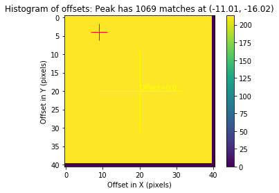

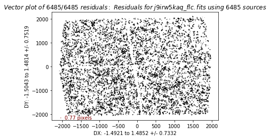

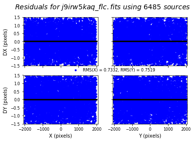

```python
tweakreg.TweakReg(input_flcs,
    #conv_width=3.5,
    #threshold=4,
    #peakmax=None,
    #searchrad=1.0,
    #fitgeometry='rscale',
    configobj = None,
    interactive=False,
    shiftfile=True,
    outshifts='shift_default.txt',
    updatehdr=False)
```

`TweakReg` looks for sources which are 4-sigma above the background, but this `threshold` value is clearly too low, since the catalogs contain ~60,000 objects per chip in each frame, and ~6500 matched sources between each exposure. Setting the `threshold` to a very low value generally does *not* translate to a better solution, since all sources are weighted equally when computing fits to match catalogs. This is especially relevant for ACS/WFC and WFC3/UVIS data where CTE tails can shift the centroid position slightly along the readout direction for faint sources and potentially bias the fit.

The shift file below shows that the xrms and yrms of the computed fit is large, ~0.7 pixels.

```python
shift_tab = Table.read('shift_default.txt',
                       format='ascii.no_header',
                       names=['file','dx','dy','rot','scale','xrms','yrms'])

formats = ['.2f', '.2f', '.3f', '.5f', '.2f', '.2f']
for i, col in enumerate(shift_tab.colnames[1:]):
    shift_tab[col].format = formats[i]
shift_tab
```

*Table length=3*

| file str18 | dx float64 | dy float64 | rot float64 | scale float64 | xrms float64 | yrms float64 |
| --- | --- | --- | --- | --- | --- | --- |
| j9irw3fwq_flc.fits | 0.00 | 0.00 | 0.000 | 1.00000 | 0.00 | 0.00 |
| j9irw4b1q_flc.fits | 10.98 | -10.00 | 360.000 | 1.00000 | 0.74 | 0.74 |
| j9irw5kaq_flc.fits | -11.00 | -16.01 | 360.000 | 1.00000 | 0.73 | 0.75 |

When `interactive` = False, `TweakReg` outputs several diagnostic plots in the working directory for you to inspect the fit quality. For each input file, except the reference file, TweakReg creates an x/y plot of fit residuals and a vector plot. Let's take a look at one of the residuals plots first.

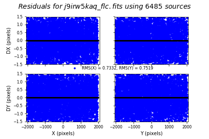

```python
#Give the 'fit residual plots' a unique name for comparison with other tests.

os.rename('residuals_j9irw5kaq_flc.png','residuals_j9irw5kaq_flc_default.png')
Image(filename='residuals_j9irw5kaq_flc_default.png', width=500, height=600)
```

### 2b. Second test: Increase `threshold`, `peakmax`

In this test, the `threshold` value was manually adjusted to a larger value, and the `peakmax` value was set to 70,000 electrons to exclude full-well saturated objects for gain=2. `TweakReg` now finds a more reasonable number of sources per ACS chip (~500) but fails to find an adequate number of sources matching the reference image due to a `searchrad` value of 1.0", which is too small.

```
INFO:drizzlepac.util:Setting up logfile :  tweakreg.log
```

```
Setting up logfile :  tweakreg.log
```

```
INFO:drizzlepac.tweakreg:TweakReg Version 1.4.7(18-April-2018) started at: 06:13:58.848 (20/03/2019)
```

```
TweakReg Version 1.4.7(18-April-2018) started at: 06:13:58.848 (20/03/2019)
```

```
INFO:drizzlepac.tweakreg:
```

```
INFO:drizzlepac.util:Version Information
```

```
Version Information
```

```
INFO:drizzlepac.util:--------------------
```

```
INFO:drizzlepac.util:Python Version [GCC 7.3.0]
```

```
Python Version [GCC 7.3.0]
```

```
INFO:drizzlepac.util:3.6.8 |Anaconda, Inc.| (default, Dec 30 2018, 01:22:34)
```

```
3.6.8 |Anaconda, Inc.| (default, Dec 30 2018, 01:22:34)
```

```
INFO:drizzlepac.util:numpy Version -> 1.15.4
```

```
numpy Version -> 1.15.4
```

```
INFO:drizzlepac.util:astropy Version -> 3.1.2
```

```
astropy Version -> 3.1.2
```

```
INFO:drizzlepac.util:stwcs Version -> 1.4.2
```

```
stwcs Version -> 1.4.2
```

```
INFO:drizzlepac.tweakreg:
INFO:drizzlepac.tweakreg:USER INPUT PARAMETERS common to all Processing Steps:
INFO:drizzlepac.tweakreg:	clean :	False
INFO:drizzlepac.tweakreg:	enforce_user_order :	True
INFO:drizzlepac.tweakreg:	exclusions :
INFO:drizzlepac.tweakreg:	expand_refcat :	False
INFO:drizzlepac.tweakreg:	input :	['j9irw3fwq_flc.fits', 'j9irw4b1q_flc.fits', 'j9irw5kaq_flc.fits']
INFO:drizzlepac.tweakreg:	interactive :	False
INFO:drizzlepac.tweakreg:	refimage :
INFO:drizzlepac.tweakreg:	runfile :	tweakreg.log
INFO:drizzlepac.tweakreg:	updatewcs :	False
INFO:drizzlepac.tweakreg:	verbose :	False
INFO:drizzlepac.tweakreg:	writecat :	True
INFO:drizzlepac.tweakreg:
```

```
INFO:drizzlepac.tweakreg:Finding shifts for:
```

```
Finding shifts for:
```

```
INFO:drizzlepac.tweakreg:    j9irw3fwq_flc.fits
```

```
    j9irw3fwq_flc.fits
```

```
INFO:drizzlepac.tweakreg:    j9irw4b1q_flc.fits
```

```
    j9irw4b1q_flc.fits
```

```
INFO:drizzlepac.tweakreg:    j9irw5kaq_flc.fits
```

```
    j9irw5kaq_flc.fits
```

```
INFO:drizzlepac.tweakreg:
```

[output not shown]

```
===  Source finding for image 'j9irw3fwq_flc.fits':
```

```
INFO:drizzlepac.catalogs:  #  Source finding for 'j9irw3fwq_flc.fits', EXT=('SCI', 1) started at: 06:13:59.032 (20/03/2019)
```

```
  #  Source finding for 'j9irw3fwq_flc.fits', EXT=('SCI', 1) started at: 06:13:59.032 (20/03/2019)
```

```
INFO:drizzlepac.catalogs:   Finding sources using sky sigma = 8.055593
INFO:drizzlepac.catalogs:###Source finding finished at: 06:13:59.754 (20/03/2019)
INFO:drizzlepac.catalogs:     Found 626 objects.
```

```
     Found 626 objects.
```

```
INFO:drizzlepac.catalogs:  #  Source finding for 'j9irw3fwq_flc.fits', EXT=('SCI', 2) started at: 06:13:59.825 (20/03/2019)
```

```
  #  Source finding for 'j9irw3fwq_flc.fits', EXT=('SCI', 2) started at: 06:13:59.825 (20/03/2019)
```

```
INFO:drizzlepac.catalogs:   Finding sources using sky sigma = 7.690619
INFO:drizzlepac.catalogs:###Source finding finished at: 06:14:00.591 (20/03/2019)
INFO:drizzlepac.catalogs:     Found 404 objects.
```

```
     Found 404 objects.
```

```
INFO:drizzlepac.imgclasses:===  FINAL number of objects in image 'j9irw3fwq_flc.fits': 1030
```

```
===  FINAL number of objects in image 'j9irw3fwq_flc.fits': 1030
```

```
INFO:drizzlepac.imgclasses:
```

```
INFO:drizzlepac.imgclasses:===  Source finding for image 'j9irw4b1q_flc.fits':
```

```
===  Source finding for image 'j9irw4b1q_flc.fits':
```

```
INFO:drizzlepac.catalogs:  #  Source finding for 'j9irw4b1q_flc.fits', EXT=('SCI', 1) started at: 06:14:00.799 (20/03/2019)
```

```
  #  Source finding for 'j9irw4b1q_flc.fits', EXT=('SCI', 1) started at: 06:14:00.799 (20/03/2019)
```

```
INFO:drizzlepac.catalogs:   Finding sources using sky sigma = 7.959351
INFO:drizzlepac.catalogs:###Source finding finished at: 06:14:01.565 (20/03/2019)
INFO:drizzlepac.catalogs:     Found 703 objects.
```

```
     Found 703 objects.
```

```
INFO:drizzlepac.catalogs:  #  Source finding for 'j9irw4b1q_flc.fits', EXT=('SCI', 2) started at: 06:14:01.636 (20/03/2019)
```

```
  #  Source finding for 'j9irw4b1q_flc.fits', EXT=('SCI', 2) started at: 06:14:01.636 (20/03/2019)
```

```
INFO:drizzlepac.catalogs:   Finding sources using sky sigma = 7.464318
INFO:drizzlepac.catalogs:###Source finding finished at: 06:14:02.320 (20/03/2019)
INFO:drizzlepac.catalogs:     Found 404 objects.
```

```
     Found 404 objects.
```

```
INFO:drizzlepac.imgclasses:===  FINAL number of objects in image 'j9irw4b1q_flc.fits': 1107
```

```
===  FINAL number of objects in image 'j9irw4b1q_flc.fits': 1107
```

```
INFO:drizzlepac.imgclasses:
```

```
INFO:drizzlepac.imgclasses:===  Source finding for image 'j9irw5kaq_flc.fits':
```

```
===  Source finding for image 'j9irw5kaq_flc.fits':
```

```
INFO:drizzlepac.catalogs:  #  Source finding for 'j9irw5kaq_flc.fits', EXT=('SCI', 1) started at: 06:14:02.549 (20/03/2019)
```

```
  #  Source finding for 'j9irw5kaq_flc.fits', EXT=('SCI', 1) started at: 06:14:02.549 (20/03/2019)
```

```
INFO:drizzlepac.catalogs:   Finding sources using sky sigma = 9.314131
INFO:drizzlepac.catalogs:###Source finding finished at: 06:14:03.252 (20/03/2019)
INFO:drizzlepac.catalogs:     Found 524 objects.
```

```
     Found 524 objects.
```

```
INFO:drizzlepac.catalogs:  #  Source finding for 'j9irw5kaq_flc.fits', EXT=('SCI', 2) started at: 06:14:03.322 (20/03/2019)
```

```
  #  Source finding for 'j9irw5kaq_flc.fits', EXT=('SCI', 2) started at: 06:14:03.322 (20/03/2019)
```

```
INFO:drizzlepac.catalogs:   Finding sources using sky sigma = 9.037025
INFO:drizzlepac.catalogs:###Source finding finished at: 06:14:04.025 (20/03/2019)
INFO:drizzlepac.catalogs:     Found 341 objects.
```

```
     Found 341 objects.
```

```
INFO:drizzlepac.imgclasses:===  FINAL number of objects in image 'j9irw5kaq_flc.fits': 865
```

```
===  FINAL number of objects in image 'j9irw5kaq_flc.fits': 865
```

```
INFO:drizzlepac.imgclasses:
```

```
INFO:drizzlepac.imgclasses:Converting RA/Dec positions of reference sources from "j9irw3fwq_flc.fits" to X,Y positions in reference WCS...
INFO:drizzlepac.tweakreg:
```

```
INFO:drizzlepac.tweakreg:===============================================================
```

```
INFO:drizzlepac.tweakreg:Performing alignment in the projection plane defined by the WCS
```

```
Performing alignment in the projection plane defined by the WCS
```

```
INFO:drizzlepac.tweakreg:derived from 'j9irw3fwq_flc.fits'
```

```
derived from 'j9irw3fwq_flc.fits'
```

```
INFO:drizzlepac.tweakreg:===============================================================
```

```
INFO:drizzlepac.tweakreg:
```

```
INFO:drizzlepac.tweakreg:USER INPUT PARAMETERS for matching sources:
INFO:drizzlepac.tweakreg:	minobj :	15
INFO:drizzlepac.tweakreg:	residplot :	both
INFO:drizzlepac.tweakreg:	searchrad :	1.0
INFO:drizzlepac.tweakreg:	searchunits :	arcseconds
INFO:drizzlepac.tweakreg:	see2dplot :	True
INFO:drizzlepac.tweakreg:	separation :	0.5
INFO:drizzlepac.tweakreg:	tolerance :	1.0
INFO:drizzlepac.tweakreg:	use2dhist :	True
INFO:drizzlepac.tweakreg:	xoffset :	0.0
INFO:drizzlepac.tweakreg:	yoffset :	0.0
INFO:drizzlepac.tweakreg:
INFO:drizzlepac.tweakreg:USER INPUT PARAMETERS for fitting source lists:
INFO:drizzlepac.tweakreg:	fitgeometry :	rscale
INFO:drizzlepac.tweakreg:	labelsize :	8
INFO:drizzlepac.tweakreg:	minobj :	15
INFO:drizzlepac.tweakreg:	nclip :	3
INFO:drizzlepac.tweakreg:	residplot :	both
INFO:drizzlepac.tweakreg:	sigma :	3.0
INFO:drizzlepac.tweakreg:	ylimit :	None
INFO:drizzlepac.tweakreg:
INFO:drizzlepac.tweakreg:USER INPUT PARAMETERS for creating a shiftfile:
INFO:drizzlepac.tweakreg:	outshifts :	shift_thresh.txt
INFO:drizzlepac.tweakreg:	outwcs :	shifts_wcs.fits
INFO:drizzlepac.tweakreg:	shiftfile :	True
INFO:drizzlepac.tweakreg:
```

```
INFO:drizzlepac.tweakreg:====================
```

```
INFO:drizzlepac.tweakreg:Performing fit for: j9irw4b1q_flc.fits
```

```
Performing fit for: j9irw4b1q_flc.fits
```

```
INFO:drizzlepac.tweakreg:
```

```
INFO:drizzlepac.imgclasses:Matching sources from 'j9irw4b1q_flc.fits' with sources from reference image 'j9irw3fwq_flc.fits'
```

```
Matching sources from 'j9irw4b1q_flc.fits' with sources from reference image 'j9irw3fwq_flc.fits'
```

```
INFO:drizzlepac.tweakutils:Computing initial guess for X and Y shifts...
```

```
Computing initial guess for X and Y shifts...
```

```
INFO:stsci.imagestats:! WARNING: Clipped data falls within 1 histogram bin
```

```
! WARNING: Clipped data falls within 1 histogram bin
```

```
INFO:drizzlepac.tweakutils:Found initial X and Y shifts of  2.0 -10.8
```

```
Found initial X and Y shifts of  2.0 -10.8
```

```
INFO:drizzlepac.tweakutils:    with significance of  116.61903789690601 and  2.0  matches
```

```
    with significance of  116.61903789690601 and  2.0  matches
```

```
WARNING:drizzlepac.imgclasses:##############################################################################
WARNING:drizzlepac.imgclasses:#                                                                            #
WARNING:drizzlepac.imgclasses:# WARNING:                                                                   #
WARNING:drizzlepac.imgclasses:# Not enough matches (< 15) found for input image: j9irw4b1q_flc.fits        #
WARNING:drizzlepac.imgclasses:#                                                                            #
WARNING:drizzlepac.imgclasses:##############################################################################
INFO:drizzlepac.imgclasses:##############################################################################
```

```
##############################################################################
```

```
INFO:drizzlepac.imgclasses:#                                                                            #
```

```
#                                                                            #
```

```
INFO:drizzlepac.imgclasses:# WARNING:                                                                   #
```

```
# WARNING:                                                                   #
```

```
INFO:drizzlepac.imgclasses:# Not enough matches (< 15) found for input image: j9irw4b1q_flc.fits        #
```

```
# Not enough matches (< 15) found for input image: j9irw4b1q_flc.fits        #
```

```
INFO:drizzlepac.imgclasses:#                                                                            #
```

```
#                                                                            #
```

```
INFO:drizzlepac.imgclasses:##############################################################################
```

```
##############################################################################
```

```
INFO:drizzlepac.tweakreg:
```

```
INFO:drizzlepac.tweakreg:====================
```

```
INFO:drizzlepac.tweakreg:Performing fit for: j9irw5kaq_flc.fits
```

```
Performing fit for: j9irw5kaq_flc.fits
```

```
INFO:drizzlepac.tweakreg:
```

```
INFO:drizzlepac.imgclasses:Matching sources from 'j9irw5kaq_flc.fits' with sources from reference image 'j9irw3fwq_flc.fits'
```

```
Matching sources from 'j9irw5kaq_flc.fits' with sources from reference image 'j9irw3fwq_flc.fits'
```

```
INFO:drizzlepac.tweakutils:Computing initial guess for X and Y shifts...
```

```
Computing initial guess for X and Y shifts...
```

```
INFO:stsci.imagestats:! WARNING: Clipped data falls within 1 histogram bin
```

```
! WARNING: Clipped data falls within 1 histogram bin
```

```
INFO:drizzlepac.tweakutils:Found initial X and Y shifts of  3.666666666666668 -12.0
```

```
Found initial X and Y shifts of  3.666666666666668 -12.0
```

```
INFO:drizzlepac.tweakutils:    with significance of  121.19405926034494 and  2.0  matches
```

```
    with significance of  121.19405926034494 and  2.0  matches
```

```
WARNING:drizzlepac.imgclasses:##############################################################################
WARNING:drizzlepac.imgclasses:#                                                                            #
WARNING:drizzlepac.imgclasses:# WARNING:                                                                   #
WARNING:drizzlepac.imgclasses:# Not enough matches (< 15) found for input image: j9irw5kaq_flc.fits        #
WARNING:drizzlepac.imgclasses:#                                                                            #
WARNING:drizzlepac.imgclasses:##############################################################################
INFO:drizzlepac.imgclasses:##############################################################################
```

```
##############################################################################
```

```
INFO:drizzlepac.imgclasses:#                                                                            #
```

```
#                                                                            #
```

```
INFO:drizzlepac.imgclasses:# WARNING:                                                                   #
```

```
# WARNING:                                                                   #
```

```
INFO:drizzlepac.imgclasses:# Not enough matches (< 15) found for input image: j9irw5kaq_flc.fits        #
```

```
# Not enough matches (< 15) found for input image: j9irw5kaq_flc.fits        #
```

```
INFO:drizzlepac.imgclasses:#                                                                            #
```

```
#                                                                            #
```

```
INFO:drizzlepac.imgclasses:##############################################################################
```

```
##############################################################################
```

```
INFO:drizzlepac.tweakreg:
```

```
INFO:drizzlepac.tweakreg:Unable to match the following images:
```

```
Unable to match the following images:
```

```
INFO:drizzlepac.tweakreg:-------------------------------------
```

```
INFO:drizzlepac.tweakreg:j9irw4b1q_flc.fits
```

```
j9irw4b1q_flc.fits
```

```
INFO:drizzlepac.tweakreg:j9irw5kaq_flc.fits
```

```
j9irw5kaq_flc.fits
```

```
INFO:drizzlepac.tweakreg:
```

```
INFO:drizzlepac.tweakutils:Writing out shiftfile : shift_thresh.txt
```

```
Writing out shiftfile : shift_thresh.txt
```

```
INFO:drizzlepac.util:Trailer file written to:  tweakreg.log
```

```
Trailer file written to:  tweakreg.log
```

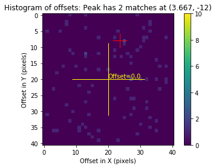

```python
tweakreg.TweakReg(input_flcs,
    #conv_width=3.5,
    threshold=4000,
    #searchrad=1.0,
    peakmax=70000,
    #fitgeometry='rscale',
    configobj = None,
    interactive=False,
    shiftfile=True,
    outshifts='shift_thresh.txt',
    updatehdr=False)
```

### 2c. Third test: Increase `searchrad`

In this test, the `searchrad` value was increased to a larger value of 4.0". This large offset is atypical for current HST observations which have more accurate Guide Star positions, but is sometimes required for older observations, such as these taken in 2006.

```
INFO:drizzlepac.util:Setting up logfile :  tweakreg.log
```

```
Setting up logfile :  tweakreg.log
```

```
INFO:drizzlepac.tweakreg:TweakReg Version 1.4.7(18-April-2018) started at: 06:14:04.739 (20/03/2019)
```

```
TweakReg Version 1.4.7(18-April-2018) started at: 06:14:04.739 (20/03/2019)
```

```
INFO:drizzlepac.tweakreg:
```

```
INFO:drizzlepac.util:Version Information
```

```
Version Information
```

```
INFO:drizzlepac.util:--------------------
```

```
INFO:drizzlepac.util:Python Version [GCC 7.3.0]
```

```
Python Version [GCC 7.3.0]
```

```
INFO:drizzlepac.util:3.6.8 |Anaconda, Inc.| (default, Dec 30 2018, 01:22:34)
```

```
3.6.8 |Anaconda, Inc.| (default, Dec 30 2018, 01:22:34)
```

```
INFO:drizzlepac.util:numpy Version -> 1.15.4
```

```
numpy Version -> 1.15.4
```

```
INFO:drizzlepac.util:astropy Version -> 3.1.2
```

```
astropy Version -> 3.1.2
```

```
INFO:drizzlepac.util:stwcs Version -> 1.4.2
```

```
stwcs Version -> 1.4.2
```

```
INFO:drizzlepac.tweakreg:
INFO:drizzlepac.tweakreg:USER INPUT PARAMETERS common to all Processing Steps:
INFO:drizzlepac.tweakreg:	clean :	False
INFO:drizzlepac.tweakreg:	enforce_user_order :	True
INFO:drizzlepac.tweakreg:	exclusions :
INFO:drizzlepac.tweakreg:	expand_refcat :	False
INFO:drizzlepac.tweakreg:	input :	['j9irw3fwq_flc.fits', 'j9irw4b1q_flc.fits', 'j9irw5kaq_flc.fits']
INFO:drizzlepac.tweakreg:	interactive :	False
INFO:drizzlepac.tweakreg:	refimage :
INFO:drizzlepac.tweakreg:	runfile :	tweakreg.log
INFO:drizzlepac.tweakreg:	updatewcs :	False
INFO:drizzlepac.tweakreg:	verbose :	False
INFO:drizzlepac.tweakreg:	writecat :	True
INFO:drizzlepac.tweakreg:
```

```
INFO:drizzlepac.tweakreg:Finding shifts for:
```

```
Finding shifts for:
```

```
INFO:drizzlepac.tweakreg:    j9irw3fwq_flc.fits
```

```
    j9irw3fwq_flc.fits
```

```
INFO:drizzlepac.tweakreg:    j9irw4b1q_flc.fits
```

```
    j9irw4b1q_flc.fits
```

```
INFO:drizzlepac.tweakreg:    j9irw5kaq_flc.fits
```

```
    j9irw5kaq_flc.fits
```

```
INFO:drizzlepac.tweakreg:
```

```
INFO:drizzlepac.tweakreg:USER INPUT PARAMETERS for finding sources for each input image:
INFO:drizzlepac.tweakreg:	clean :	False
INFO:drizzlepac.tweakreg:	computesig :	True
INFO:drizzlepac.tweakreg:	conv_width :	3.5
INFO:drizzlepac.tweakreg:	dqbits :
INFO:drizzlepac.tweakreg:	enforce_user_order :	True
INFO:drizzlepac.tweakreg:	expand_refcat :	False
INFO:drizzlepac.tweakreg:	fluxmax :	None
INFO:drizzlepac.tweakreg:	fluxmin :	None
INFO:drizzlepac.tweakreg:	input :	['j9irw3fwq_flc.fits', 'j9irw4b1q_flc.fits', 'j9irw5kaq_flc.fits']
INFO:drizzlepac.tweakreg:	interactive :	False
INFO:drizzlepac.tweakreg:	nsigma :	1.5
INFO:drizzlepac.tweakreg:	peakmax :	70000
INFO:drizzlepac.tweakreg:	peakmin :	None
INFO:drizzlepac.tweakreg:	ratio :	1.0
INFO:drizzlepac.tweakreg:	refimage :
INFO:drizzlepac.tweakreg:	roundhi :	1.0
INFO:drizzlepac.tweakreg:	roundlo :	-1.0
INFO:drizzlepac.tweakreg:	runfile :	tweakreg.log
INFO:drizzlepac.tweakreg:	sharphi :	1.0
INFO:drizzlepac.tweakreg:	sharplo :	0.2
INFO:drizzlepac.tweakreg:	skysigma :	0.0
INFO:drizzlepac.tweakreg:	theta :	0.0
INFO:drizzlepac.tweakreg:	threshold :	4000
INFO:drizzlepac.tweakreg:	updatehdr :	False
INFO:drizzlepac.tweakreg:	updatewcs :	False
INFO:drizzlepac.tweakreg:	use_sharp_round :	False
INFO:drizzlepac.tweakreg:	verbose :	False
INFO:drizzlepac.tweakreg:	writecat :	True
INFO:drizzlepac.tweakreg:	xyunits :	pixels
INFO:drizzlepac.tweakreg:
INFO:drizzlepac.imgclasses:===  Source finding for image 'j9irw3fwq_flc.fits':
```

```
===  Source finding for image 'j9irw3fwq_flc.fits':
```

```
INFO:drizzlepac.catalogs:  #  Source finding for 'j9irw3fwq_flc.fits', EXT=('SCI', 1) started at: 06:14:04.901 (20/03/2019)
```

```
  #  Source finding for 'j9irw3fwq_flc.fits', EXT=('SCI', 1) started at: 06:14:04.901 (20/03/2019)
```

```
INFO:drizzlepac.catalogs:   Finding sources using sky sigma = 8.055593
INFO:drizzlepac.catalogs:###Source finding finished at: 06:14:05.607 (20/03/2019)
INFO:drizzlepac.catalogs:     Found 626 objects.
```

```
     Found 626 objects.
```

```
INFO:drizzlepac.catalogs:  #  Source finding for 'j9irw3fwq_flc.fits', EXT=('SCI', 2) started at: 06:14:05.678 (20/03/2019)
```

```
  #  Source finding for 'j9irw3fwq_flc.fits', EXT=('SCI', 2) started at: 06:14:05.678 (20/03/2019)
```

```
INFO:drizzlepac.catalogs:   Finding sources using sky sigma = 7.690619
INFO:drizzlepac.catalogs:###Source finding finished at: 06:14:06.39 (20/03/2019)
INFO:drizzlepac.catalogs:     Found 404 objects.
```

```
     Found 404 objects.
```

```
INFO:drizzlepac.imgclasses:===  FINAL number of objects in image 'j9irw3fwq_flc.fits': 1030
```

```
===  FINAL number of objects in image 'j9irw3fwq_flc.fits': 1030
```

```
INFO:drizzlepac.imgclasses:
```

```
INFO:drizzlepac.imgclasses:===  Source finding for image 'j9irw4b1q_flc.fits':
```

```
===  Source finding for image 'j9irw4b1q_flc.fits':
```

```
INFO:drizzlepac.catalogs:  #  Source finding for 'j9irw4b1q_flc.fits', EXT=('SCI', 1) started at: 06:14:06.604 (20/03/2019)
```

```
  #  Source finding for 'j9irw4b1q_flc.fits', EXT=('SCI', 1) started at: 06:14:06.604 (20/03/2019)
```

```
INFO:drizzlepac.catalogs:   Finding sources using sky sigma = 7.959351
INFO:drizzlepac.catalogs:###Source finding finished at: 06:14:07.311 (20/03/2019)
INFO:drizzlepac.catalogs:     Found 703 objects.
```

```
     Found 703 objects.
```

```
INFO:drizzlepac.catalogs:  #  Source finding for 'j9irw4b1q_flc.fits', EXT=('SCI', 2) started at: 06:14:07.382 (20/03/2019)
```

```
  #  Source finding for 'j9irw4b1q_flc.fits', EXT=('SCI', 2) started at: 06:14:07.382 (20/03/2019)
```

```
INFO:drizzlepac.catalogs:   Finding sources using sky sigma = 7.464318
INFO:drizzlepac.catalogs:###Source finding finished at: 06:14:08.13 (20/03/2019)
INFO:drizzlepac.catalogs:     Found 404 objects.
```

```
     Found 404 objects.
```

```
INFO:drizzlepac.imgclasses:===  FINAL number of objects in image 'j9irw4b1q_flc.fits': 1107
```

```
===  FINAL number of objects in image 'j9irw4b1q_flc.fits': 1107
```

```
INFO:drizzlepac.imgclasses:
```

```
INFO:drizzlepac.imgclasses:===  Source finding for image 'j9irw5kaq_flc.fits':
```

```
===  Source finding for image 'j9irw5kaq_flc.fits':
```

```
INFO:drizzlepac.catalogs:  #  Source finding for 'j9irw5kaq_flc.fits', EXT=('SCI', 1) started at: 06:14:08.359 (20/03/2019)
```

```
  #  Source finding for 'j9irw5kaq_flc.fits', EXT=('SCI', 1) started at: 06:14:08.359 (20/03/2019)
```

```
INFO:drizzlepac.catalogs:   Finding sources using sky sigma = 9.314131
INFO:drizzlepac.catalogs:###Source finding finished at: 06:14:09.129 (20/03/2019)
INFO:drizzlepac.catalogs:     Found 524 objects.
```

```
     Found 524 objects.
```

```
INFO:drizzlepac.catalogs:  #  Source finding for 'j9irw5kaq_flc.fits', EXT=('SCI', 2) started at: 06:14:09.198 (20/03/2019)
```

```
  #  Source finding for 'j9irw5kaq_flc.fits', EXT=('SCI', 2) started at: 06:14:09.198 (20/03/2019)
```

```
INFO:drizzlepac.catalogs:   Finding sources using sky sigma = 9.037025
INFO:drizzlepac.catalogs:###Source finding finished at: 06:14:09.944 (20/03/2019)
INFO:drizzlepac.catalogs:     Found 341 objects.
```

```
     Found 341 objects.
```

```
INFO:drizzlepac.imgclasses:===  FINAL number of objects in image 'j9irw5kaq_flc.fits': 865
```

```
===  FINAL number of objects in image 'j9irw5kaq_flc.fits': 865
```

```
INFO:drizzlepac.imgclasses:
```

```
INFO:drizzlepac.imgclasses:Converting RA/Dec positions of reference sources from "j9irw3fwq_flc.fits" to X,Y positions in reference WCS...
INFO:drizzlepac.tweakreg:
```

```
INFO:drizzlepac.tweakreg:===============================================================
```

```
INFO:drizzlepac.tweakreg:Performing alignment in the projection plane defined by the WCS
```

```
Performing alignment in the projection plane defined by the WCS
```

```
INFO:drizzlepac.tweakreg:derived from 'j9irw3fwq_flc.fits'
```

```
derived from 'j9irw3fwq_flc.fits'
```

```
INFO:drizzlepac.tweakreg:===============================================================
```

```
INFO:drizzlepac.tweakreg:
```

```
INFO:drizzlepac.tweakreg:USER INPUT PARAMETERS for matching sources:
INFO:drizzlepac.tweakreg:	minobj :	15
INFO:drizzlepac.tweakreg:	residplot :	both
INFO:drizzlepac.tweakreg:	searchrad :	4.0
INFO:drizzlepac.tweakreg:	searchunits :	arcseconds
INFO:drizzlepac.tweakreg:	see2dplot :	True
INFO:drizzlepac.tweakreg:	separation :	0.5
INFO:drizzlepac.tweakreg:	tolerance :	1.0
INFO:drizzlepac.tweakreg:	use2dhist :	True
INFO:drizzlepac.tweakreg:	xoffset :	0.0
INFO:drizzlepac.tweakreg:	yoffset :	0.0
INFO:drizzlepac.tweakreg:
INFO:drizzlepac.tweakreg:USER INPUT PARAMETERS for fitting source lists:
INFO:drizzlepac.tweakreg:	fitgeometry :	rscale
INFO:drizzlepac.tweakreg:	labelsize :	8
INFO:drizzlepac.tweakreg:	minobj :	15
INFO:drizzlepac.tweakreg:	nclip :	3
INFO:drizzlepac.tweakreg:	residplot :	both
INFO:drizzlepac.tweakreg:	sigma :	3.0
INFO:drizzlepac.tweakreg:	ylimit :	None
INFO:drizzlepac.tweakreg:
INFO:drizzlepac.tweakreg:USER INPUT PARAMETERS for creating a shiftfile:
INFO:drizzlepac.tweakreg:	outshifts :	shift_searchrad.txt
INFO:drizzlepac.tweakreg:	outwcs :	shifts_wcs.fits
INFO:drizzlepac.tweakreg:	shiftfile :	True
INFO:drizzlepac.tweakreg:
```

```
INFO:drizzlepac.tweakreg:====================
```

```
INFO:drizzlepac.tweakreg:Performing fit for: j9irw4b1q_flc.fits
```

```
Performing fit for: j9irw4b1q_flc.fits
```

```
INFO:drizzlepac.tweakreg:
```

```
INFO:drizzlepac.imgclasses:Matching sources from 'j9irw4b1q_flc.fits' with sources from reference image 'j9irw3fwq_flc.fits'
```

```
Matching sources from 'j9irw4b1q_flc.fits' with sources from reference image 'j9irw3fwq_flc.fits'
```

```
INFO:drizzlepac.tweakutils:Computing initial guess for X and Y shifts...
```

```
Computing initial guess for X and Y shifts...
```

```
INFO:drizzlepac.tweakutils:Found initial X and Y shifts of  -30.621739130434783 -40.99130434782609
```

```
Found initial X and Y shifts of  -30.621739130434783 -40.99130434782609
```

```
INFO:drizzlepac.tweakutils:    with significance of  6856.673130040089 and  428.0  matches
```

```
    with significance of  6856.673130040089 and  428.0  matches
```

```
INFO:drizzlepac.imgclasses:Found 690 matches for j9irw4b1q_flc.fits...
```

```
Found 690 matches for j9irw4b1q_flc.fits...
```

```
INFO:drizzlepac.linearfit:Performing "rscale" fit
INFO:drizzlepac.linearfit:Performing "rscale" fit
INFO:drizzlepac.linearfit:Performing "rscale" fit
INFO:drizzlepac.linearfit:Performing "rscale" fit
INFO:drizzlepac.imgclasses:Computed  rscale  fit for  j9irw4b1q_flc.fits :
```

```
Computed  rscale  fit for  j9irw4b1q_flc.fits :
```

```
INFO:drizzlepac.imgclasses:XSH: -30.0086  YSH: -40.1901    ROT: 0.004397630633    SCALE: 1.000010
```

```
XSH: -30.0086  YSH: -40.1901    ROT: 0.004397630633    SCALE: 1.000010
```

```
INFO:drizzlepac.imgclasses:XRMS: 0.039    YRMS: 0.038
```

```
XRMS: 0.039    YRMS: 0.038
```

```
INFO:drizzlepac.imgclasses:
```

```
INFO:drizzlepac.imgclasses:RMS_RA: 4.7e-07 (deg)   RMS_DEC: 7.5e-07 (deg)
```

```
RMS_RA: 4.7e-07 (deg)   RMS_DEC: 7.5e-07 (deg)
```

```
INFO:drizzlepac.imgclasses:
```

```
INFO:drizzlepac.imgclasses:Final solution based on  680  objects.
```

```
Final solution based on  680  objects.
```

```
INFO:drizzlepac.imgclasses:Creating catalog for the fit: j9irw4b1q_flc_catalog_fit.match
INFO:drizzlepac.tweakutils:wrote XY data to:  j9irw4b1q_flc_catalog_fit.match
```

```
wrote XY data to:  j9irw4b1q_flc_catalog_fit.match
```

```
INFO:drizzlepac.tweakutils:Total # points:  680
```

```
Total # points:  680
```

```
INFO:drizzlepac.tweakutils:# of points after clipping:  680
```

```
# of points after clipping:  680
```

```
INFO:drizzlepac.tweakutils:Total # points:  680
```

```
Total # points:  680
```

```
INFO:drizzlepac.tweakutils:# of points after clipping:  680
```

```
# of points after clipping:  680
```

[output not shown]

```
INFO:drizzlepac.tweakreg:====================
```

```
INFO:drizzlepac.tweakreg:Performing fit for: j9irw5kaq_flc.fits
```

```
Performing fit for: j9irw5kaq_flc.fits
```

```
INFO:drizzlepac.tweakreg:
```

```
INFO:drizzlepac.imgclasses:Matching sources from 'j9irw5kaq_flc.fits' with sources from reference image 'j9irw3fwq_flc.fits'
```

```
Matching sources from 'j9irw5kaq_flc.fits' with sources from reference image 'j9irw3fwq_flc.fits'
```

```
INFO:drizzlepac.tweakutils:Computing initial guess for X and Y shifts...
```

```
Computing initial guess for X and Y shifts...
```

```
INFO:drizzlepac.tweakutils:Found initial X and Y shifts of  -10.0 -30.0196905766526
```

```
Found initial X and Y shifts of  -10.0 -30.0196905766526
```

```
INFO:drizzlepac.tweakutils:    with significance of  30564.731440011048 and  697.0  matches
```

```
    with significance of  30564.731440011048 and  697.0  matches
```

```
INFO:drizzlepac.imgclasses:Found 711 matches for j9irw5kaq_flc.fits...
```

```
Found 711 matches for j9irw5kaq_flc.fits...
```

```
INFO:drizzlepac.linearfit:Performing "rscale" fit
INFO:drizzlepac.linearfit:Performing "rscale" fit
INFO:drizzlepac.linearfit:Performing "rscale" fit
INFO:drizzlepac.linearfit:Performing "rscale" fit
INFO:drizzlepac.imgclasses:Computed  rscale  fit for  j9irw5kaq_flc.fits :
```

```
Computed  rscale  fit for  j9irw5kaq_flc.fits :
```

```
INFO:drizzlepac.imgclasses:XSH: -9.6516  YSH: -29.8824    ROT: 0.0007297714734    SCALE: 1.000010
```

```
XSH: -9.6516  YSH: -29.8824    ROT: 0.0007297714734    SCALE: 1.000010
```

```
INFO:drizzlepac.imgclasses:XRMS: 0.05    YRMS: 0.05
```

```
XRMS: 0.05    YRMS: 0.05
```

```
INFO:drizzlepac.imgclasses:
```

```
INFO:drizzlepac.imgclasses:RMS_RA: 6.5e-07 (deg)   RMS_DEC: 9.7e-07 (deg)
```

```
RMS_RA: 6.5e-07 (deg)   RMS_DEC: 9.7e-07 (deg)
```

```
INFO:drizzlepac.imgclasses:
```

```
INFO:drizzlepac.imgclasses:Final solution based on  702  objects.
```

```
Final solution based on  702  objects.
```

```
INFO:drizzlepac.imgclasses:Creating catalog for the fit: j9irw5kaq_flc_catalog_fit.match
INFO:drizzlepac.tweakutils:wrote XY data to:  j9irw5kaq_flc_catalog_fit.match
```

```
wrote XY data to:  j9irw5kaq_flc_catalog_fit.match
```

```
INFO:drizzlepac.tweakutils:Total # points:  702
```

```
Total # points:  702
```

```
INFO:drizzlepac.tweakutils:# of points after clipping:  702
```

```
# of points after clipping:  702
```

```
INFO:drizzlepac.tweakutils:Total # points:  702
```

```
Total # points:  702
```

```
INFO:drizzlepac.tweakutils:# of points after clipping:  702
```

```
# of points after clipping:  702
```

[output not shown]

```
Writing out shiftfile : shift_searchrad.txt
```

```
INFO:drizzlepac.util:Trailer file written to:  tweakreg.log
```

```
Trailer file written to:  tweakreg.log
```

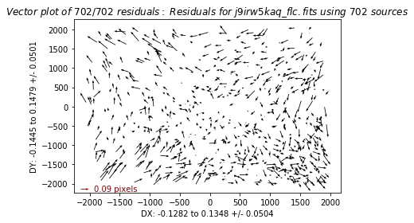

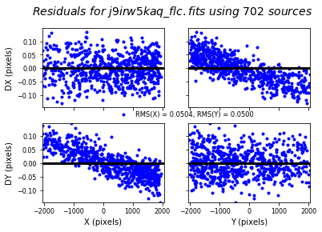

```python
tweakreg.TweakReg(input_flcs,
    #conv_width=3.5,
    threshold=4000,
    searchrad=4.0,
    peakmax=70000,
    #fitgeometry='rscale',
    configobj = None,
    interactive=False,
    shiftfile=True,
    outshifts='shift_searchrad.txt',
    updatehdr=False)
```

The shift file below shows that the xrms and yrms of the computed fit is now ~0.05 pixels.

```python
shift_tab=Table.read('shift_searchrad.txt',
                     format='ascii.no_header',
                     names=['file','dx','dy','rot','scale','xrms','yrms'])

formats = ['.2f', '.2f', '.3f', '.5f', '.2f', '.2f']
for i, col in enumerate(shift_tab.colnames[1:]):
    shift_tab[col].format = formats[i]
shift_tab
```

*Table length=3*

| file str18 | dx float64 | dy float64 | rot float64 | scale float64 | xrms float64 | yrms float64 |
| --- | --- | --- | --- | --- | --- | --- |
| j9irw3fwq_flc.fits | 0.00 | 0.00 | 0.000 | 1.00000 | 0.00 | 0.00 |
| j9irw4b1q_flc.fits | -30.01 | -40.19 | 0.004 | 1.00001 | 0.04 | 0.04 |
| j9irw5kaq_flc.fits | -9.65 | -29.88 | 0.001 | 1.00001 | 0.05 | 0.05 |

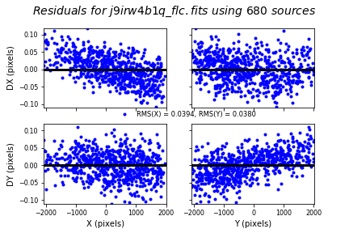

```python
#Give the 'fit residual plots' a unique name for comparison with other tests.

os.rename('residuals_j9irw4b1q_flc.png','residuals_j9irw4b1q_flc_searchrad.png')
Image(filename='residuals_j9irw4b1q_flc_searchrad.png', width=500, height=600)
```

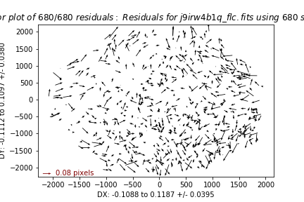

```python
#Give the 'fit residual plots' a unique name for comparison with other tests.

os.rename('vector_j9irw4b1q_flc.png', 'vector_j9irw4b1q_flc_searchrad.png')
Image(filename='vector_j9irw4b1q_flc_searchrad.png', width=500, height=600)
```

The residual plots are now much improved from the first run, but there is still a systematic skew in the fit residuals, which is believed to be caused by an uncorrected 'skew' in the ACS distortion solution.

As of creation of this notebook in 2018, the following calibration reference files were used:

```
    IDCTAB  = 'jref$0461802ej_idc.fits' / Image Distortion Correction Table
D2IMFILE = 'jref$02c1450oj_d2i.fits' / Column Correction Reference File
    NPOLFILE = 'jref$02c14514j_npl.fits' / Non-polynomial Offsets Reference File (F606W)
```

New distortion solutions, based on the latest Gaia DR2, are in the process of being derived by the ACS team, so observations retrieved from MAST at a later date may or may not show these systematic skew residuals. Fortunately, these can be corrected by allowing for a higher order `fitgeometry` as shown in the next test.

More information about the distortion reference files used by `AstroDrizzle` may be found [here](http://documents.stsci.edu/hst/HST_overview/documents/DrizzlePac/ch33.html).

### 2d. Fourth test: Adjust the `fitgeometry`

In this test, the `fitgeometry` parameter is changed from the default 'rscale' to 'general' in order to allows for an xy/shift and an independent scale and rotation for each axis.

```
INFO:drizzlepac.util:Setting up logfile :  tweakreg.log
```

```
Setting up logfile :  tweakreg.log
```

```
INFO:drizzlepac.tweakreg:TweakReg Version 1.4.7(18-April-2018) started at: 06:14:12.19 (20/03/2019)
```

```
TweakReg Version 1.4.7(18-April-2018) started at: 06:14:12.19 (20/03/2019)
```

```
INFO:drizzlepac.tweakreg:
```

```
INFO:drizzlepac.util:Version Information
```

```
Version Information
```

```
INFO:drizzlepac.util:--------------------
```

```
INFO:drizzlepac.util:Python Version [GCC 7.3.0]
```

```
Python Version [GCC 7.3.0]
```

```
INFO:drizzlepac.util:3.6.8 |Anaconda, Inc.| (default, Dec 30 2018, 01:22:34)
```

```
3.6.8 |Anaconda, Inc.| (default, Dec 30 2018, 01:22:34)
```

```
INFO:drizzlepac.util:numpy Version -> 1.15.4
```

```
numpy Version -> 1.15.4
```

```
INFO:drizzlepac.util:astropy Version -> 3.1.2
```

```
astropy Version -> 3.1.2
```

```
INFO:drizzlepac.util:stwcs Version -> 1.4.2
```

```
stwcs Version -> 1.4.2
```

```
INFO:drizzlepac.tweakreg:
INFO:drizzlepac.tweakreg:USER INPUT PARAMETERS common to all Processing Steps:
INFO:drizzlepac.tweakreg:	clean :	False
INFO:drizzlepac.tweakreg:	enforce_user_order :	True
INFO:drizzlepac.tweakreg:	exclusions :
INFO:drizzlepac.tweakreg:	expand_refcat :	False
INFO:drizzlepac.tweakreg:	input :	['j9irw3fwq_flc.fits', 'j9irw4b1q_flc.fits', 'j9irw5kaq_flc.fits']
INFO:drizzlepac.tweakreg:	interactive :	False
INFO:drizzlepac.tweakreg:	refimage :
INFO:drizzlepac.tweakreg:	runfile :	tweakreg.log
INFO:drizzlepac.tweakreg:	updatewcs :	False
INFO:drizzlepac.tweakreg:	verbose :	False
INFO:drizzlepac.tweakreg:	writecat :	True
INFO:drizzlepac.tweakreg:
```

```
INFO:drizzlepac.tweakreg:Finding shifts for:
```

```
Finding shifts for:
```

```
INFO:drizzlepac.tweakreg:    j9irw3fwq_flc.fits
```

```
    j9irw3fwq_flc.fits
```

```
INFO:drizzlepac.tweakreg:    j9irw4b1q_flc.fits
```

```
    j9irw4b1q_flc.fits
```

```
INFO:drizzlepac.tweakreg:    j9irw5kaq_flc.fits
```

```
    j9irw5kaq_flc.fits
```

```
INFO:drizzlepac.tweakreg:
```

[output not shown]

```
===  Source finding for image 'j9irw3fwq_flc.fits':
```

```
INFO:drizzlepac.catalogs:  #  Source finding for 'j9irw3fwq_flc.fits', EXT=('SCI', 1) started at: 06:14:12.366 (20/03/2019)
```

```
  #  Source finding for 'j9irw3fwq_flc.fits', EXT=('SCI', 1) started at: 06:14:12.366 (20/03/2019)
```

```
INFO:drizzlepac.catalogs:   Finding sources using sky sigma = 8.055593
INFO:drizzlepac.catalogs:###Source finding finished at: 06:14:13.096 (20/03/2019)
INFO:drizzlepac.catalogs:     Found 626 objects.
```

```
     Found 626 objects.
```

```
INFO:drizzlepac.catalogs:  #  Source finding for 'j9irw3fwq_flc.fits', EXT=('SCI', 2) started at: 06:14:13.168 (20/03/2019)
```

```
  #  Source finding for 'j9irw3fwq_flc.fits', EXT=('SCI', 2) started at: 06:14:13.168 (20/03/2019)
```

```
INFO:drizzlepac.catalogs:   Finding sources using sky sigma = 7.690619
INFO:drizzlepac.catalogs:###Source finding finished at: 06:14:13.874 (20/03/2019)
INFO:drizzlepac.catalogs:     Found 404 objects.
```

```
     Found 404 objects.
```

```
INFO:drizzlepac.imgclasses:===  FINAL number of objects in image 'j9irw3fwq_flc.fits': 1030
```

```
===  FINAL number of objects in image 'j9irw3fwq_flc.fits': 1030
```

```
INFO:drizzlepac.imgclasses:
```

```
INFO:drizzlepac.imgclasses:===  Source finding for image 'j9irw4b1q_flc.fits':
```

```
===  Source finding for image 'j9irw4b1q_flc.fits':
```

```
INFO:drizzlepac.catalogs:  #  Source finding for 'j9irw4b1q_flc.fits', EXT=('SCI', 1) started at: 06:14:14.088 (20/03/2019)
```

```
  #  Source finding for 'j9irw4b1q_flc.fits', EXT=('SCI', 1) started at: 06:14:14.088 (20/03/2019)
```

```
INFO:drizzlepac.catalogs:   Finding sources using sky sigma = 7.959351
INFO:drizzlepac.catalogs:###Source finding finished at: 06:14:14.815 (20/03/2019)
INFO:drizzlepac.catalogs:     Found 703 objects.
```

```
     Found 703 objects.
```

```
INFO:drizzlepac.catalogs:  #  Source finding for 'j9irw4b1q_flc.fits', EXT=('SCI', 2) started at: 06:14:14.889 (20/03/2019)
```

```
  #  Source finding for 'j9irw4b1q_flc.fits', EXT=('SCI', 2) started at: 06:14:14.889 (20/03/2019)
```

```
INFO:drizzlepac.catalogs:   Finding sources using sky sigma = 7.464318
INFO:drizzlepac.catalogs:###Source finding finished at: 06:14:15.600 (20/03/2019)
INFO:drizzlepac.catalogs:     Found 404 objects.
```

```
     Found 404 objects.
```

```
INFO:drizzlepac.imgclasses:===  FINAL number of objects in image 'j9irw4b1q_flc.fits': 1107
```

```
===  FINAL number of objects in image 'j9irw4b1q_flc.fits': 1107
```

```
INFO:drizzlepac.imgclasses:
```

```
INFO:drizzlepac.imgclasses:===  Source finding for image 'j9irw5kaq_flc.fits':
```

```
===  Source finding for image 'j9irw5kaq_flc.fits':
```

```
INFO:drizzlepac.catalogs:  #  Source finding for 'j9irw5kaq_flc.fits', EXT=('SCI', 1) started at: 06:14:15.83 (20/03/2019)
```

```
  #  Source finding for 'j9irw5kaq_flc.fits', EXT=('SCI', 1) started at: 06:14:15.83 (20/03/2019)
```

```
INFO:drizzlepac.catalogs:   Finding sources using sky sigma = 9.314131
INFO:drizzlepac.catalogs:###Source finding finished at: 06:14:16.518 (20/03/2019)
INFO:drizzlepac.catalogs:     Found 524 objects.
```

```
     Found 524 objects.
```

```
INFO:drizzlepac.catalogs:  #  Source finding for 'j9irw5kaq_flc.fits', EXT=('SCI', 2) started at: 06:14:16.589 (20/03/2019)
```

```
  #  Source finding for 'j9irw5kaq_flc.fits', EXT=('SCI', 2) started at: 06:14:16.589 (20/03/2019)
```

```
INFO:drizzlepac.catalogs:   Finding sources using sky sigma = 9.037025
INFO:drizzlepac.catalogs:###Source finding finished at: 06:14:17.369 (20/03/2019)
INFO:drizzlepac.catalogs:     Found 341 objects.
```

```
     Found 341 objects.
```

```
INFO:drizzlepac.imgclasses:===  FINAL number of objects in image 'j9irw5kaq_flc.fits': 865
```

```
===  FINAL number of objects in image 'j9irw5kaq_flc.fits': 865
```

```
INFO:drizzlepac.imgclasses:
```

```
INFO:drizzlepac.imgclasses:Converting RA/Dec positions of reference sources from "j9irw3fwq_flc.fits" to X,Y positions in reference WCS...
INFO:drizzlepac.tweakreg:
```

```
INFO:drizzlepac.tweakreg:===============================================================
```

```
INFO:drizzlepac.tweakreg:Performing alignment in the projection plane defined by the WCS
```

```
Performing alignment in the projection plane defined by the WCS
```

```
INFO:drizzlepac.tweakreg:derived from 'j9irw3fwq_flc.fits'
```

```
derived from 'j9irw3fwq_flc.fits'
```

```
INFO:drizzlepac.tweakreg:===============================================================
```

```
INFO:drizzlepac.tweakreg:
```

```
INFO:drizzlepac.tweakreg:USER INPUT PARAMETERS for matching sources:
INFO:drizzlepac.tweakreg:	minobj :	15
INFO:drizzlepac.tweakreg:	residplot :	both
INFO:drizzlepac.tweakreg:	searchrad :	4.0
INFO:drizzlepac.tweakreg:	searchunits :	arcseconds
INFO:drizzlepac.tweakreg:	see2dplot :	True
INFO:drizzlepac.tweakreg:	separation :	0.5
INFO:drizzlepac.tweakreg:	tolerance :	1.0
INFO:drizzlepac.tweakreg:	use2dhist :	True
INFO:drizzlepac.tweakreg:	xoffset :	0.0
INFO:drizzlepac.tweakreg:	yoffset :	0.0
INFO:drizzlepac.tweakreg:
INFO:drizzlepac.tweakreg:USER INPUT PARAMETERS for fitting source lists:
INFO:drizzlepac.tweakreg:	fitgeometry :	general
INFO:drizzlepac.tweakreg:	labelsize :	8
INFO:drizzlepac.tweakreg:	minobj :	15
INFO:drizzlepac.tweakreg:	nclip :	3
INFO:drizzlepac.tweakreg:	residplot :	both
INFO:drizzlepac.tweakreg:	sigma :	3.0
INFO:drizzlepac.tweakreg:	ylimit :	None
INFO:drizzlepac.tweakreg:
INFO:drizzlepac.tweakreg:USER INPUT PARAMETERS for creating a shiftfile:
INFO:drizzlepac.tweakreg:	outshifts :	shift_general.txt
INFO:drizzlepac.tweakreg:	outwcs :	shifts_wcs.fits
INFO:drizzlepac.tweakreg:	shiftfile :	True
INFO:drizzlepac.tweakreg:
```

```
INFO:drizzlepac.tweakreg:====================
```

```
INFO:drizzlepac.tweakreg:Performing fit for: j9irw4b1q_flc.fits
```

```
Performing fit for: j9irw4b1q_flc.fits
```

```
INFO:drizzlepac.tweakreg:
```

```
INFO:drizzlepac.imgclasses:Matching sources from 'j9irw4b1q_flc.fits' with sources from reference image 'j9irw3fwq_flc.fits'
```

```
Matching sources from 'j9irw4b1q_flc.fits' with sources from reference image 'j9irw3fwq_flc.fits'
```

```
INFO:drizzlepac.tweakutils:Computing initial guess for X and Y shifts...
```

```
Computing initial guess for X and Y shifts...
```

```
INFO:drizzlepac.tweakutils:Found initial X and Y shifts of  -30.621739130434783 -40.99130434782609
```

```
Found initial X and Y shifts of  -30.621739130434783 -40.99130434782609
```

```
INFO:drizzlepac.tweakutils:    with significance of  6856.673130040089 and  428.0  matches
```

```
    with significance of  6856.673130040089 and  428.0  matches
```

```
INFO:drizzlepac.imgclasses:Found 690 matches for j9irw4b1q_flc.fits...
```

```
Found 690 matches for j9irw4b1q_flc.fits...
```

```
INFO:drizzlepac.linearfit:Performing "general" fit
INFO:drizzlepac.linearfit:Performing "general" fit
INFO:drizzlepac.linearfit:Performing "general" fit
INFO:drizzlepac.linearfit:Performing "general" fit
INFO:drizzlepac.imgclasses:Computed  general  fit for  j9irw4b1q_flc.fits :
```

```
Computed  general  fit for  j9irw4b1q_flc.fits :
```

```
INFO:drizzlepac.imgclasses:XSH: -30.0042  YSH: -40.1841    PROPER ROT: 0.004468546459
```

```
XSH: -30.0042  YSH: -40.1841    PROPER ROT: 0.004468546459
```

```
INFO:drizzlepac.imgclasses:<ROT>: 0.004468546459  SKEW: -0.0008172839833    ROT_X: 0.00487718845  ROT_Y: 0.004059904467
```

```
<ROT>: 0.004468546459  SKEW: -0.0008172839833    ROT_X: 0.00487718845  ROT_Y: 0.004059904467
```

```
INFO:drizzlepac.imgclasses:<SCALE>: 1.000008798  SCALE_X: 0.9999868771  SCALE_Y: 1.00003072
```

```
<SCALE>: 1.000008798  SCALE_X: 0.9999868771  SCALE_Y: 1.00003072
```

```
INFO:drizzlepac.imgclasses:XRMS: 0.032    YRMS: 0.03
```

```
XRMS: 0.032    YRMS: 0.03
```

```
INFO:drizzlepac.imgclasses:
```

```
INFO:drizzlepac.imgclasses:RMS_RA: 3.7e-07 (deg)   RMS_DEC: 6e-07 (deg)
```

```
RMS_RA: 3.7e-07 (deg)   RMS_DEC: 6e-07 (deg)
```

```
INFO:drizzlepac.imgclasses:
```

```
INFO:drizzlepac.imgclasses:Final solution based on  680  objects.
```

```
Final solution based on  680  objects.
```

```
INFO:drizzlepac.imgclasses:Creating catalog for the fit: j9irw4b1q_flc_catalog_fit.match
INFO:drizzlepac.tweakutils:wrote XY data to:  j9irw4b1q_flc_catalog_fit.match
```

```
wrote XY data to:  j9irw4b1q_flc_catalog_fit.match
```

```
INFO:drizzlepac.tweakutils:Total # points:  680
```

```
Total # points:  680
```

```
INFO:drizzlepac.tweakutils:# of points after clipping:  680
```

```
# of points after clipping:  680
```

```
INFO:drizzlepac.tweakutils:Total # points:  680
```

```
Total # points:  680
```

```
INFO:drizzlepac.tweakutils:# of points after clipping:  680
```

```
# of points after clipping:  680
```

[output not shown]

```
INFO:drizzlepac.tweakreg:====================
```

```
INFO:drizzlepac.tweakreg:Performing fit for: j9irw5kaq_flc.fits
```

```
Performing fit for: j9irw5kaq_flc.fits
```

```
INFO:drizzlepac.tweakreg:
```

```
INFO:drizzlepac.imgclasses:Matching sources from 'j9irw5kaq_flc.fits' with sources from reference image 'j9irw3fwq_flc.fits'
```

```
Matching sources from 'j9irw5kaq_flc.fits' with sources from reference image 'j9irw3fwq_flc.fits'
```

```
INFO:drizzlepac.tweakutils:Computing initial guess for X and Y shifts...
```

```
Computing initial guess for X and Y shifts...
```

```
INFO:drizzlepac.tweakutils:Found initial X and Y shifts of  -10.0 -30.0196905766526
```

```
Found initial X and Y shifts of  -10.0 -30.0196905766526
```

```
INFO:drizzlepac.tweakutils:    with significance of  30564.731440011048 and  697.0  matches
```

```
    with significance of  30564.731440011048 and  697.0  matches
```

```
INFO:drizzlepac.imgclasses:Found 711 matches for j9irw5kaq_flc.fits...
```

```
Found 711 matches for j9irw5kaq_flc.fits...
```

```
INFO:drizzlepac.linearfit:Performing "general" fit
INFO:drizzlepac.linearfit:Performing "general" fit
INFO:drizzlepac.linearfit:Performing "general" fit
INFO:drizzlepac.linearfit:Performing "general" fit
INFO:drizzlepac.imgclasses:Computed  general  fit for  j9irw5kaq_flc.fits :
```

```
Computed  general  fit for  j9irw5kaq_flc.fits :
```

```
INFO:drizzlepac.imgclasses:XSH: -9.6614  YSH: -29.8731    PROPER ROT: 0.0007630584289
```

```
XSH: -9.6614  YSH: -29.8731    PROPER ROT: 0.0007630584289
```

```
INFO:drizzlepac.imgclasses:<ROT>: 180.0007631  SKEW: 359.9958898    ROT_X: 0.002818152887  ROT_Y: 359.998708
```

```
<ROT>: 180.0007631  SKEW: 359.9958898    ROT_X: 0.002818152887  ROT_Y: 359.998708
```

```
INFO:drizzlepac.imgclasses:<SCALE>: 1.000008179  SCALE_X: 1.000008792  SCALE_Y: 1.000007569
```

```
<SCALE>: 1.000008179  SCALE_X: 1.000008792  SCALE_Y: 1.000007569
```

```
INFO:drizzlepac.imgclasses:XRMS: 0.031    YRMS: 0.029
```

```
XRMS: 0.031    YRMS: 0.029
```

```
INFO:drizzlepac.imgclasses:
```

```
INFO:drizzlepac.imgclasses:RMS_RA: 3.4e-07 (deg)   RMS_DEC: 5.9e-07 (deg)
```

```
RMS_RA: 3.4e-07 (deg)   RMS_DEC: 5.9e-07 (deg)
```

```
INFO:drizzlepac.imgclasses:
```

```
INFO:drizzlepac.imgclasses:Final solution based on  699  objects.
```

```
Final solution based on  699  objects.
```

```
INFO:drizzlepac.imgclasses:Creating catalog for the fit: j9irw5kaq_flc_catalog_fit.match
INFO:drizzlepac.tweakutils:wrote XY data to:  j9irw5kaq_flc_catalog_fit.match
```

```
wrote XY data to:  j9irw5kaq_flc_catalog_fit.match
```

```
INFO:drizzlepac.tweakutils:Total # points:  699
```

```
Total # points:  699
```

```
INFO:drizzlepac.tweakutils:# of points after clipping:  699
```

```
# of points after clipping:  699
```

```
INFO:drizzlepac.tweakutils:Total # points:  699
```

```
Total # points:  699
```

```
INFO:drizzlepac.tweakutils:# of points after clipping:  699
```

```
# of points after clipping:  699
```

[output not shown]

```
Writing out shiftfile : shift_general.txt
```

```
INFO:drizzlepac.util:Trailer file written to:  tweakreg.log
```

```
Trailer file written to:  tweakreg.log
```

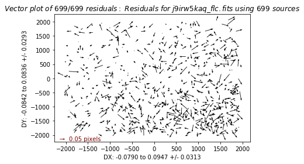

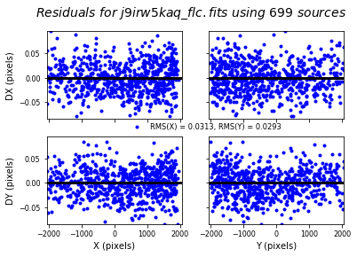

```python
tweakreg.TweakReg(input_flcs,
    #conv_width=3.5,
    threshold=4000,
    searchrad=4.0,
    peakmax=70000,
    fitgeometry='general',
    configobj = None,
    interactive=False,
    shiftfile=True,
    outshifts='shift_general.txt',
    updatehdr=False)
```

```python
shift_tab=Table.read('shift_general.txt',
                     format='ascii.no_header',
                     names=['file','dx','dy','rot','scale','xrms','yrms'])

formats = ['.2f', '.2f', '.3f', '.5f', '.2f', '.2f']
for i, col in enumerate(shift_tab.colnames[1:]):
    shift_tab[col].format = formats[i]
shift_tab
```

*Table length=3*

| file str18 | dx float64 | dy float64 | rot float64 | scale float64 | xrms float64 | yrms float64 |
| --- | --- | --- | --- | --- | --- | --- |
| j9irw3fwq_flc.fits | 0.00 | 0.00 | 0.000 | 1.00000 | 0.00 | 0.00 |
| j9irw4b1q_flc.fits | -30.00 | -40.18 | 0.004 | 1.00001 | 0.03 | 0.03 |
| j9irw5kaq_flc.fits | -9.66 | -29.87 | 0.001 | 1.00001 | 0.03 | 0.03 |

While the shift file looks nearly identical to the prior run, this is because the axis-dependent rotation and scale values are averaged together in the shiftfile. To determine the actual values, it is necessary to inspect the logfile.

```
j9irw5kaq  SCALE_X: 1.000008792  SCALE_Y: 1.00000757  ROT_X: 0.002818152  ROT_Y: 359.998708  SKEW: 359.9958898
j9irw4b1q  SCALE_X: 0.999986877  SCALE_Y: 1.00003072  ROT_X: 0.004877188  ROT_Y: 0.00405990  SKEW:  -0.0008173
```

The 'general' fit reduces the fit rms to ~0.03 pixels from the prior value of ~0.05 pixels and removes systematics from the residuals.

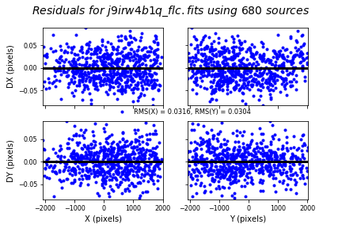

```python
#Give the 'fit residual plots' a unique name for comparison with other tests.

os.rename('residuals_j9irw4b1q_flc.png', 'residuals_j9irw4b1q_flc_general.png')
Image(filename='residuals_j9irw4b1q_flc_general.png', width=500, height=600)
```

The plot above shows residuals in X and Y plotted as functions of X and Y. Each point represents a source that was used for the alignment. The residuals should look fairly random - if any correlation is seen, this is an indicator of a poor alignment solution. In some cases you will notice a wavy pattern in the residuals in X and Y. This is often seen for UVIS images and is a result of lithographic patterns of the detector that are not fully corrected for in the distortion solutions. The RMS in X and Y are also printed. For a good alignment, we are looking for an RMS on the order of 0.1 pixel or less.

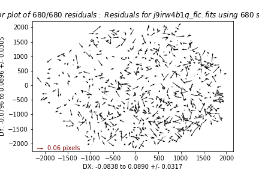

```python
#Give the 'vector residual plots' a unique name for comparison with other tests.

os.rename('vector_j9irw4b1q_flc.png', 'vector_j9irw4b1q_flc_general.png')
Image(filename='vector_j9irw4b1q_flc_general.png', width=500, height=600)
```

The direction and the magnitude of the arrows in the vector plot above represent the offsets in the source position between the image in question and the reference image. These should visually appear random if the alignment was sucessful.

You may need to run `TweakReg` run several times with varying parameters until a good fit is found. Notice in the above tests that `updatehdr = False`. This allows you to attempt the alignment and inspect the results without actually updating the WCS to solidify the alignment. Once you are satisfied with the results, `TweakReg` is run a final time with `updatehdr = True`, and a new WCS will be inserted in the file. The default name of this new WCS is 'TWEAK', but can be changed by setting the `wcsname`.

### 2e. Update header once optimal parameters are found

```
INFO:drizzlepac.util:Setting up logfile :  tweakreg.log
```

```
Setting up logfile :  tweakreg.log
```

```
INFO:drizzlepac.tweakreg:TweakReg Version 1.4.7(18-April-2018) started at: 06:14:19.583 (20/03/2019)
```

```
TweakReg Version 1.4.7(18-April-2018) started at: 06:14:19.583 (20/03/2019)
```

```
INFO:drizzlepac.tweakreg:
```

```
INFO:drizzlepac.util:Version Information
```

```
Version Information
```

```
INFO:drizzlepac.util:--------------------
```

```
INFO:drizzlepac.util:Python Version [GCC 7.3.0]
```

```
Python Version [GCC 7.3.0]
```

```
INFO:drizzlepac.util:3.6.8 |Anaconda, Inc.| (default, Dec 30 2018, 01:22:34)
```

```
3.6.8 |Anaconda, Inc.| (default, Dec 30 2018, 01:22:34)
```

```
INFO:drizzlepac.util:numpy Version -> 1.15.4
```

```
numpy Version -> 1.15.4
```

```
INFO:drizzlepac.util:astropy Version -> 3.1.2
```

```
astropy Version -> 3.1.2
```

```
INFO:drizzlepac.util:stwcs Version -> 1.4.2
```

```
stwcs Version -> 1.4.2
```

```
INFO:drizzlepac.tweakreg:
INFO:drizzlepac.tweakreg:USER INPUT PARAMETERS common to all Processing Steps:
INFO:drizzlepac.tweakreg:	clean :	False
INFO:drizzlepac.tweakreg:	enforce_user_order :	True
INFO:drizzlepac.tweakreg:	exclusions :
INFO:drizzlepac.tweakreg:	expand_refcat :	False
INFO:drizzlepac.tweakreg:	input :	['j9irw3fwq_flc.fits', 'j9irw4b1q_flc.fits', 'j9irw5kaq_flc.fits']
INFO:drizzlepac.tweakreg:	interactive :	False
INFO:drizzlepac.tweakreg:	refimage :
INFO:drizzlepac.tweakreg:	runfile :	tweakreg.log
INFO:drizzlepac.tweakreg:	updatewcs :	False
INFO:drizzlepac.tweakreg:	verbose :	False
INFO:drizzlepac.tweakreg:	writecat :	True
INFO:drizzlepac.tweakreg:
```

```
INFO:drizzlepac.tweakreg:Finding shifts for:
```

```
Finding shifts for:
```

```
INFO:drizzlepac.tweakreg:    j9irw3fwq_flc.fits
```

```
    j9irw3fwq_flc.fits
```

```
INFO:drizzlepac.tweakreg:    j9irw4b1q_flc.fits
```

```
    j9irw4b1q_flc.fits
```

```
INFO:drizzlepac.tweakreg:    j9irw5kaq_flc.fits
```

```
    j9irw5kaq_flc.fits
```

```
INFO:drizzlepac.tweakreg:
```

[output not shown]

```
===  Source finding for image 'j9irw3fwq_flc.fits':
```

```
INFO:drizzlepac.catalogs:  #  Source finding for 'j9irw3fwq_flc.fits', EXT=('SCI', 1) started at: 06:14:19.863 (20/03/2019)
```

```
  #  Source finding for 'j9irw3fwq_flc.fits', EXT=('SCI', 1) started at: 06:14:19.863 (20/03/2019)
```

```
INFO:drizzlepac.catalogs:   Finding sources using sky sigma = 8.055593
INFO:drizzlepac.catalogs:###Source finding finished at: 06:14:20.604 (20/03/2019)
INFO:drizzlepac.catalogs:     Found 626 objects.
```

```
     Found 626 objects.
```

```
INFO:drizzlepac.catalogs:  #  Source finding for 'j9irw3fwq_flc.fits', EXT=('SCI', 2) started at: 06:14:20.676 (20/03/2019)
```

```
  #  Source finding for 'j9irw3fwq_flc.fits', EXT=('SCI', 2) started at: 06:14:20.676 (20/03/2019)
```

```
INFO:drizzlepac.catalogs:   Finding sources using sky sigma = 7.690619
INFO:drizzlepac.catalogs:###Source finding finished at: 06:14:21.383 (20/03/2019)
INFO:drizzlepac.catalogs:     Found 404 objects.
```

```
     Found 404 objects.
```

```
INFO:drizzlepac.imgclasses:===  FINAL number of objects in image 'j9irw3fwq_flc.fits': 1030
```

```
===  FINAL number of objects in image 'j9irw3fwq_flc.fits': 1030
```

```
INFO:drizzlepac.imgclasses:
```

```
INFO:drizzlepac.imgclasses:===  Source finding for image 'j9irw4b1q_flc.fits':
```

```
===  Source finding for image 'j9irw4b1q_flc.fits':
```

```
INFO:drizzlepac.catalogs:  #  Source finding for 'j9irw4b1q_flc.fits', EXT=('SCI', 1) started at: 06:14:21.611 (20/03/2019)
```

```
  #  Source finding for 'j9irw4b1q_flc.fits', EXT=('SCI', 1) started at: 06:14:21.611 (20/03/2019)
```

```
INFO:drizzlepac.catalogs:   Finding sources using sky sigma = 7.959351
INFO:drizzlepac.catalogs:###Source finding finished at: 06:14:22.333 (20/03/2019)
INFO:drizzlepac.catalogs:     Found 703 objects.
```

```
     Found 703 objects.
```

```
INFO:drizzlepac.catalogs:  #  Source finding for 'j9irw4b1q_flc.fits', EXT=('SCI', 2) started at: 06:14:22.404 (20/03/2019)
```

```
  #  Source finding for 'j9irw4b1q_flc.fits', EXT=('SCI', 2) started at: 06:14:22.404 (20/03/2019)
```

```
INFO:drizzlepac.catalogs:   Finding sources using sky sigma = 7.464318
INFO:drizzlepac.catalogs:###Source finding finished at: 06:14:23.115 (20/03/2019)
INFO:drizzlepac.catalogs:     Found 404 objects.
```

```
     Found 404 objects.
```

```
INFO:drizzlepac.imgclasses:===  FINAL number of objects in image 'j9irw4b1q_flc.fits': 1107
```

```
===  FINAL number of objects in image 'j9irw4b1q_flc.fits': 1107
```

```
INFO:drizzlepac.imgclasses:
```

```
INFO:drizzlepac.imgclasses:===  Source finding for image 'j9irw5kaq_flc.fits':
```

```
===  Source finding for image 'j9irw5kaq_flc.fits':
```

```
INFO:drizzlepac.catalogs:  #  Source finding for 'j9irw5kaq_flc.fits', EXT=('SCI', 1) started at: 06:14:23.454 (20/03/2019)
```

```
  #  Source finding for 'j9irw5kaq_flc.fits', EXT=('SCI', 1) started at: 06:14:23.454 (20/03/2019)
```

```
INFO:drizzlepac.catalogs:   Finding sources using sky sigma = 9.314131
INFO:drizzlepac.catalogs:###Source finding finished at: 06:14:24.261 (20/03/2019)
INFO:drizzlepac.catalogs:     Found 524 objects.
```

```
     Found 524 objects.
```

```
INFO:drizzlepac.catalogs:  #  Source finding for 'j9irw5kaq_flc.fits', EXT=('SCI', 2) started at: 06:14:24.337 (20/03/2019)
```

```
  #  Source finding for 'j9irw5kaq_flc.fits', EXT=('SCI', 2) started at: 06:14:24.337 (20/03/2019)
```

```
INFO:drizzlepac.catalogs:   Finding sources using sky sigma = 9.037025
INFO:drizzlepac.catalogs:###Source finding finished at: 06:14:25.121 (20/03/2019)
INFO:drizzlepac.catalogs:     Found 341 objects.
```

```
     Found 341 objects.
```

```
INFO:drizzlepac.imgclasses:===  FINAL number of objects in image 'j9irw5kaq_flc.fits': 865
```

```
===  FINAL number of objects in image 'j9irw5kaq_flc.fits': 865
```

```
INFO:drizzlepac.imgclasses:
```

```
INFO:drizzlepac.imgclasses:Converting RA/Dec positions of reference sources from "j9irw3fwq_flc.fits" to X,Y positions in reference WCS...
INFO:drizzlepac.tweakreg:
```

```
INFO:drizzlepac.tweakreg:===============================================================
```

```
INFO:drizzlepac.tweakreg:Performing alignment in the projection plane defined by the WCS
```

```
Performing alignment in the projection plane defined by the WCS
```

```
INFO:drizzlepac.tweakreg:derived from 'j9irw3fwq_flc.fits'
```

```
derived from 'j9irw3fwq_flc.fits'
```

```
INFO:drizzlepac.tweakreg:===============================================================
```

```
INFO:drizzlepac.tweakreg:
```

```
INFO:drizzlepac.tweakreg:USER INPUT PARAMETERS for matching sources:
INFO:drizzlepac.tweakreg:	minobj :	15
INFO:drizzlepac.tweakreg:	residplot :	both
INFO:drizzlepac.tweakreg:	searchrad :	4.0
INFO:drizzlepac.tweakreg:	searchunits :	arcseconds
INFO:drizzlepac.tweakreg:	see2dplot :	True
INFO:drizzlepac.tweakreg:	separation :	0.5
INFO:drizzlepac.tweakreg:	tolerance :	1.0
INFO:drizzlepac.tweakreg:	use2dhist :	True
INFO:drizzlepac.tweakreg:	xoffset :	0.0
INFO:drizzlepac.tweakreg:	yoffset :	0.0
INFO:drizzlepac.tweakreg:
INFO:drizzlepac.tweakreg:USER INPUT PARAMETERS for fitting source lists:
INFO:drizzlepac.tweakreg:	fitgeometry :	general
INFO:drizzlepac.tweakreg:	labelsize :	8
INFO:drizzlepac.tweakreg:	minobj :	15
INFO:drizzlepac.tweakreg:	nclip :	3
INFO:drizzlepac.tweakreg:	residplot :	both
INFO:drizzlepac.tweakreg:	sigma :	3.0
INFO:drizzlepac.tweakreg:	ylimit :	None
INFO:drizzlepac.tweakreg:
```

```
INFO:drizzlepac.tweakreg:====================
```

```
INFO:drizzlepac.tweakreg:Performing fit for: j9irw4b1q_flc.fits
```

```
Performing fit for: j9irw4b1q_flc.fits
```

```
INFO:drizzlepac.tweakreg:
```

```
INFO:drizzlepac.imgclasses:Matching sources from 'j9irw4b1q_flc.fits' with sources from reference image 'j9irw3fwq_flc.fits'
```

```
Matching sources from 'j9irw4b1q_flc.fits' with sources from reference image 'j9irw3fwq_flc.fits'
```

```
INFO:drizzlepac.tweakutils:Computing initial guess for X and Y shifts...
```

```
Computing initial guess for X and Y shifts...
```

```
INFO:drizzlepac.tweakutils:Found initial X and Y shifts of  -30.621739130434783 -40.99130434782609
```

```
Found initial X and Y shifts of  -30.621739130434783 -40.99130434782609
```

```
INFO:drizzlepac.tweakutils:    with significance of  6856.673130040089 and  428.0  matches
```

```
    with significance of  6856.673130040089 and  428.0  matches
```

```
INFO:drizzlepac.imgclasses:Found 690 matches for j9irw4b1q_flc.fits...
```

```
Found 690 matches for j9irw4b1q_flc.fits...
```

```
INFO:drizzlepac.linearfit:Performing "general" fit
INFO:drizzlepac.linearfit:Performing "general" fit
INFO:drizzlepac.linearfit:Performing "general" fit
INFO:drizzlepac.linearfit:Performing "general" fit
INFO:drizzlepac.imgclasses:Computed  general  fit for  j9irw4b1q_flc.fits :
```

```
Computed  general  fit for  j9irw4b1q_flc.fits :
```

```
INFO:drizzlepac.imgclasses:XSH: -30.0042  YSH: -40.1841    PROPER ROT: 0.004468546459
```

```
XSH: -30.0042  YSH: -40.1841    PROPER ROT: 0.004468546459
```

```
INFO:drizzlepac.imgclasses:<ROT>: 0.004468546459  SKEW: -0.0008172839833    ROT_X: 0.00487718845  ROT_Y: 0.004059904467
```

```
<ROT>: 0.004468546459  SKEW: -0.0008172839833    ROT_X: 0.00487718845  ROT_Y: 0.004059904467
```

```
INFO:drizzlepac.imgclasses:<SCALE>: 1.000008798  SCALE_X: 0.9999868771  SCALE_Y: 1.00003072
```

```
<SCALE>: 1.000008798  SCALE_X: 0.9999868771  SCALE_Y: 1.00003072
```

```
INFO:drizzlepac.imgclasses:XRMS: 0.032    YRMS: 0.03
```

```
XRMS: 0.032    YRMS: 0.03
```

```
INFO:drizzlepac.imgclasses:
```

```
INFO:drizzlepac.imgclasses:RMS_RA: 3.7e-07 (deg)   RMS_DEC: 6e-07 (deg)
```

```
RMS_RA: 3.7e-07 (deg)   RMS_DEC: 6e-07 (deg)
```

```
INFO:drizzlepac.imgclasses:
```

```
INFO:drizzlepac.imgclasses:Final solution based on  680  objects.
```

```
Final solution based on  680  objects.
```

```
INFO:drizzlepac.imgclasses:Creating catalog for the fit: j9irw4b1q_flc_catalog_fit.match
INFO:drizzlepac.tweakutils:wrote XY data to:  j9irw4b1q_flc_catalog_fit.match
```

```
wrote XY data to:  j9irw4b1q_flc_catalog_fit.match
```

```
INFO:drizzlepac.tweakutils:Total # points:  680
```

```
Total # points:  680
```

```
INFO:drizzlepac.tweakutils:# of points after clipping:  680
```

```
# of points after clipping:  680
```

```
INFO:drizzlepac.tweakutils:Total # points:  680
```

```
Total # points:  680
```

```
INFO:drizzlepac.tweakutils:# of points after clipping:  680
```

```
# of points after clipping:  680
```

```
INFO:drizzlepac.updatehdr:
```

```
INFO:drizzlepac.updatehdr:....Updating header for j9irw4b1q_flc.fits...
```

```
....Updating header for j9irw4b1q_flc.fits...
```

```
INFO:drizzlepac.updatehdr:
```

```
INFO:drizzlepac.updatehdr:
```

```
INFO:drizzlepac.updatehdr:Processing j9irw4b1q_flc.fits['SCI',1]
```

```
Processing j9irw4b1q_flc.fits['SCI',1]
```

```
INFO:drizzlepac.updatehdr:
```

```
INFO:drizzlepac.updatehdr:Updating header for j9irw4b1q_flc.fits[1]
```

```
Updating header for j9irw4b1q_flc.fits[1]
```

```
INFO:drizzlepac.updatehdr:    with WCS of
INFO:stwcs.wcsutil.hstwcs:WCS Keywords
```

```
WCS Keywords
```

```
INFO:stwcs.wcsutil.hstwcs:
```

```
INFO:stwcs.wcsutil.hstwcs:CD_11  CD_12: -1.2925691887354924e-06 -1.3971052789816462e-05
```

```
CD_11  CD_12: -1.2925691887354924e-06 -1.3971052789816462e-05
```

```
INFO:stwcs.wcsutil.hstwcs:CD_21  CD_22: -1.37874153993747e-05 3.4342533777749347e-07
```

```
CD_21  CD_22: -1.37874153993747e-05 3.4342533777749347e-07
```

```
INFO:stwcs.wcsutil.hstwcs:CRVAL    : 5.705123991576119 -72.06817128824616
```

```
CRVAL    : 5.705123991576119 -72.06817128824616
```

```
INFO:stwcs.wcsutil.hstwcs:CRPIX    : 2048.0 1024.0
```

```
CRPIX    : 2048.0 1024.0
```

```
INFO:stwcs.wcsutil.hstwcs:NAXIS    : 4096 2048
```

```
NAXIS    : 4096 2048
```

```
INFO:stwcs.wcsutil.hstwcs:Plate Scale : 0.049852182052595895
```

```
Plate Scale : 0.049852182052595895
```

```
INFO:stwcs.wcsutil.hstwcs:ORIENTAT : -88.59188416089467
```

```
ORIENTAT : -88.59188416089467
```

```
INFO:drizzlepac.updatehdr:WCSNAME  :  TWEAK
```

```
WCSNAME  :  TWEAK
```

```
INFO:drizzlepac.updatehdr:
```

```
INFO:drizzlepac.updatehdr:Processing j9irw4b1q_flc.fits['SCI',2]
```

```
Processing j9irw4b1q_flc.fits['SCI',2]
```

```
INFO:drizzlepac.updatehdr:
```

```
Updating header for j9irw4b1q_flc.fits[4]
```

```
INFO:drizzlepac.updatehdr:    with WCS of
INFO:stwcs.wcsutil.hstwcs:WCS Keywords
```

```
WCS Keywords
```

```
INFO:stwcs.wcsutil.hstwcs:
```

```
INFO:stwcs.wcsutil.hstwcs:CD_11  CD_12: -1.4809378933983524e-06 -1.3506770563446464e-05
```

```
CD_11  CD_12: -1.4809378933983524e-06 -1.3506770563446464e-05
```

```
INFO:stwcs.wcsutil.hstwcs:CD_21  CD_22: -1.3605625140100077e-05 2.498129693740875e-07
```

```
CD_21  CD_22: -1.3605625140100077e-05 2.498129693740875e-07
```

```
INFO:stwcs.wcsutil.hstwcs:CRVAL    : 5.611340698605562 -72.06749934671086
```

```
CRVAL    : 5.611340698605562 -72.06749934671086
```

```
INFO:stwcs.wcsutil.hstwcs:CRPIX    : 2048.0 1024.0
```

```
CRPIX    : 2048.0 1024.0
```

```
INFO:stwcs.wcsutil.hstwcs:NAXIS    : 4096 2048
```

```
NAXIS    : 4096 2048
```

```
INFO:stwcs.wcsutil.hstwcs:Plate Scale : 0.049269420600720766
```

```
Plate Scale : 0.049269420600720766
```

```
INFO:stwcs.wcsutil.hstwcs:ORIENTAT : -88.9404131066308
```

```
ORIENTAT : -88.9404131066308
```

```
INFO:drizzlepac.updatehdr:WCSNAME  :  TWEAK
```

```
WCSNAME  :  TWEAK
```

[output not shown]

```
INFO:drizzlepac.tweakreg:====================
```

```
INFO:drizzlepac.tweakreg:Performing fit for: j9irw5kaq_flc.fits
```

```
Performing fit for: j9irw5kaq_flc.fits
```

```
INFO:drizzlepac.tweakreg:
```

```
INFO:drizzlepac.imgclasses:Matching sources from 'j9irw5kaq_flc.fits' with sources from reference image 'j9irw3fwq_flc.fits'
```

```
Matching sources from 'j9irw5kaq_flc.fits' with sources from reference image 'j9irw3fwq_flc.fits'
```

```
INFO:drizzlepac.tweakutils:Computing initial guess for X and Y shifts...
```

```
Computing initial guess for X and Y shifts...
```

```
INFO:drizzlepac.tweakutils:Found initial X and Y shifts of  -10.0 -30.0196905766526
```

```
Found initial X and Y shifts of  -10.0 -30.0196905766526
```

```
INFO:drizzlepac.tweakutils:    with significance of  30564.731440011048 and  697.0  matches
```

```
    with significance of  30564.731440011048 and  697.0  matches
```

```
INFO:drizzlepac.imgclasses:Found 711 matches for j9irw5kaq_flc.fits...
```

```
Found 711 matches for j9irw5kaq_flc.fits...
```

```
INFO:drizzlepac.linearfit:Performing "general" fit
INFO:drizzlepac.linearfit:Performing "general" fit
INFO:drizzlepac.linearfit:Performing "general" fit
INFO:drizzlepac.linearfit:Performing "general" fit
INFO:drizzlepac.imgclasses:Computed  general  fit for  j9irw5kaq_flc.fits :
```

```
Computed  general  fit for  j9irw5kaq_flc.fits :
```

```
INFO:drizzlepac.imgclasses:XSH: -9.6614  YSH: -29.8731    PROPER ROT: 0.0007630584289
```

```
XSH: -9.6614  YSH: -29.8731    PROPER ROT: 0.0007630584289
```

```
INFO:drizzlepac.imgclasses:<ROT>: 180.0007631  SKEW: 359.9958898    ROT_X: 0.002818152887  ROT_Y: 359.998708
```

```
<ROT>: 180.0007631  SKEW: 359.9958898    ROT_X: 0.002818152887  ROT_Y: 359.998708
```

```
INFO:drizzlepac.imgclasses:<SCALE>: 1.000008179  SCALE_X: 1.000008792  SCALE_Y: 1.000007569
```

```
<SCALE>: 1.000008179  SCALE_X: 1.000008792  SCALE_Y: 1.000007569
```

```
INFO:drizzlepac.imgclasses:XRMS: 0.031    YRMS: 0.029
```

```
XRMS: 0.031    YRMS: 0.029
```

```
INFO:drizzlepac.imgclasses:
```

```
INFO:drizzlepac.imgclasses:RMS_RA: 3.4e-07 (deg)   RMS_DEC: 5.9e-07 (deg)
```

```
RMS_RA: 3.4e-07 (deg)   RMS_DEC: 5.9e-07 (deg)
```

```
INFO:drizzlepac.imgclasses:
```

```
INFO:drizzlepac.imgclasses:Final solution based on  699  objects.
```

```
Final solution based on  699  objects.
```

```
INFO:drizzlepac.imgclasses:Creating catalog for the fit: j9irw5kaq_flc_catalog_fit.match
INFO:drizzlepac.tweakutils:wrote XY data to:  j9irw5kaq_flc_catalog_fit.match
```

```
wrote XY data to:  j9irw5kaq_flc_catalog_fit.match
```

```
INFO:drizzlepac.tweakutils:Total # points:  699
```

```
Total # points:  699
```

```
INFO:drizzlepac.tweakutils:# of points after clipping:  699
```

```
# of points after clipping:  699
```

```
INFO:drizzlepac.tweakutils:Total # points:  699
```

```
Total # points:  699
```

```
INFO:drizzlepac.tweakutils:# of points after clipping:  699
```

```
# of points after clipping:  699
```

```
INFO:drizzlepac.updatehdr:
```

```
INFO:drizzlepac.updatehdr:....Updating header for j9irw5kaq_flc.fits...
```

```
....Updating header for j9irw5kaq_flc.fits...
```

```
INFO:drizzlepac.updatehdr:
```

```
INFO:drizzlepac.updatehdr:
```

```
INFO:drizzlepac.updatehdr:Processing j9irw5kaq_flc.fits['SCI',1]
```

```
Processing j9irw5kaq_flc.fits['SCI',1]
```

```
INFO:drizzlepac.updatehdr:
```

```
Updating header for j9irw5kaq_flc.fits[1]
```

```
INFO:drizzlepac.updatehdr:    with WCS of
INFO:stwcs.wcsutil.hstwcs:WCS Keywords
```

```
WCS Keywords
```

```
INFO:stwcs.wcsutil.hstwcs:
```

```
INFO:stwcs.wcsutil.hstwcs:CD_11  CD_12: -1.2283148710161914e-05 -7.289506408936989e-06
```

```
CD_11  CD_12: -1.2283148710161914e-05 -7.289506408936989e-06
```

```
INFO:stwcs.wcsutil.hstwcs:CD_21  CD_22: -6.392653476646905e-06 1.1923204531948128e-05
```

```
CD_21  CD_22: -6.392653476646905e-06 1.1923204531948128e-05
```

```
INFO:stwcs.wcsutil.hstwcs:CRVAL    : 5.684923465753231 -72.07974027387641
```

```
CRVAL    : 5.684923465753231 -72.07974027387641
```

```
INFO:stwcs.wcsutil.hstwcs:CRPIX    : 2048.0 1024.0
```

```
CRPIX    : 2048.0 1024.0
```

```
INFO:stwcs.wcsutil.hstwcs:NAXIS    : 4096 2048
```

```
NAXIS    : 4096 2048
```

```
INFO:stwcs.wcsutil.hstwcs:Plate Scale : 0.049850226704326456
```

```
Plate Scale : 0.049850226704326456
```

```
INFO:stwcs.wcsutil.hstwcs:ORIENTAT : -31.440423258734477
```

```
ORIENTAT : -31.440423258734477
```

```
INFO:drizzlepac.updatehdr:WCSNAME  :  TWEAK
```

```
WCSNAME  :  TWEAK
```

```
INFO:drizzlepac.updatehdr:
```

```
INFO:drizzlepac.updatehdr:Processing j9irw5kaq_flc.fits['SCI',2]
```

```
Processing j9irw5kaq_flc.fits['SCI',2]
```

```
INFO:drizzlepac.updatehdr:
```

```
Updating header for j9irw5kaq_flc.fits[4]
```

```
INFO:drizzlepac.updatehdr:    with WCS of
INFO:stwcs.wcsutil.hstwcs:WCS Keywords
```

```
WCS Keywords
```

```
INFO:stwcs.wcsutil.hstwcs:
```

```
INFO:stwcs.wcsutil.hstwcs:CD_11  CD_12: -1.222805092817223e-05 -7.124838078718109e-06
```

```
CD_11  CD_12: -1.222805092817223e-05 -7.124838078718109e-06
```

```
INFO:stwcs.wcsutil.hstwcs:CD_21  CD_22: -6.144881055652223e-06 1.1477101290262778e-05
```

```
CD_21  CD_22: -6.144881055652223e-06 1.1477101290262778e-05
```

```
INFO:stwcs.wcsutil.hstwcs:CRVAL    : 5.635859438523883 -72.05512383390565
```

```
CRVAL    : 5.635859438523883 -72.05512383390565
```

```
INFO:stwcs.wcsutil.hstwcs:CRPIX    : 2048.0 1024.0
```

```
CRPIX    : 2048.0 1024.0
```

```
INFO:stwcs.wcsutil.hstwcs:NAXIS    : 4096 2048
```

```
NAXIS    : 4096 2048
```

```
INFO:stwcs.wcsutil.hstwcs:Plate Scale : 0.04926749132987825
```

```
Plate Scale : 0.04926749132987825
```

```
INFO:stwcs.wcsutil.hstwcs:ORIENTAT : -31.831482785875636
```

```
ORIENTAT : -31.831482785875636
```

```
INFO:drizzlepac.updatehdr:WCSNAME  :  TWEAK
```

```
WCSNAME  :  TWEAK
```

[output not shown]

[output cut: 14 more lines]

[output not shown]

```
Trailer file written to:  tweakreg.log
```

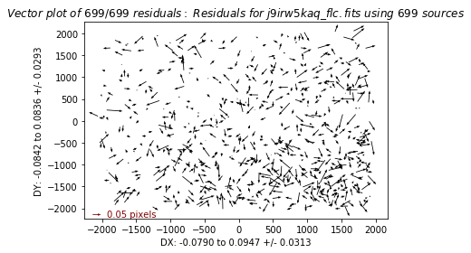

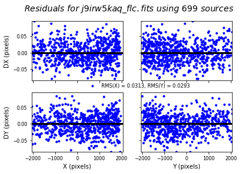

```python
# Final run with ideal parameters, updatehdr = True

tweakreg.TweakReg(input_flcs,
    conv_width=3.5,
    threshold=4000,
    searchrad=4.0,
    peakmax=70000,
    fitgeometry='general',
    configobj = None,
    interactive=False,
    shiftfile=False,
    updatehdr=True)
```

### 2f. Overplot Matched Sources on the Image

Let's plot the sources that were matched between all images on the bottom chip. Confusingly, this is referred to as 'chip 2' or SCI,1 or extension 1.

The cell below shows how to read in the `*_fit.match` file as an `astropy` table. Unfortunatley, it doesn't automatically name columns so you'll have to look at the header to grab the columns.

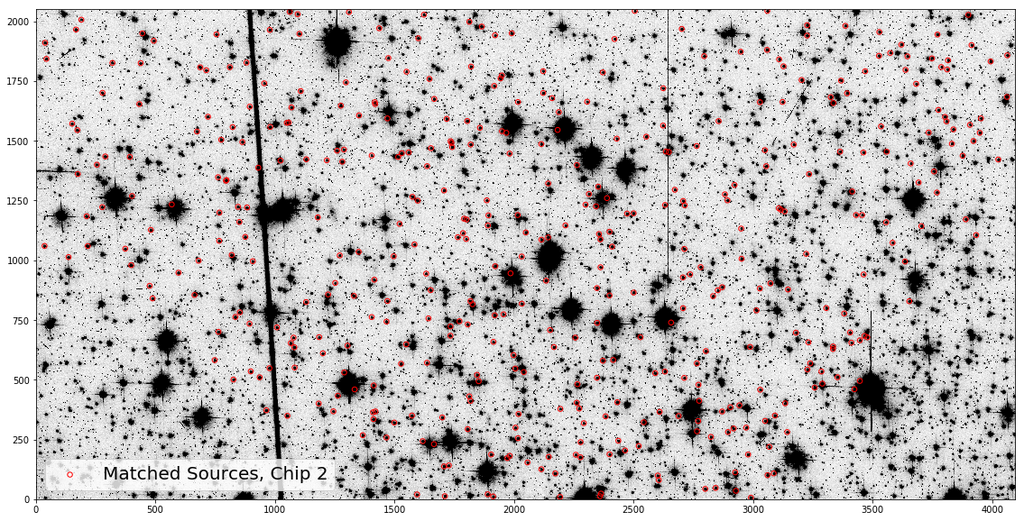

```python
plt.figure(figsize = (20, 10))
chip1_data = fits.open('j9irw4b1q_flc.fits')['SCI', 1].data
zscale = ZScaleInterval()
z1, z2 = zscale.get_limits(chip1_data)
plt.imshow(chip1_data, cmap='Greys',origin='lower', vmin=z1, vmax=z2)

match_tab = ascii.read('j9irw4b1q_flc_catalog_fit.match')            #load match file in astropy table
match_tab_chip2 = match_tab[match_tab['col15'] == 1]                 #filter table for sources on chip 2 (on ext 1)
x_cord, y_cord = match_tab_chip2['col11'], match_tab_chip2['col12']

plt.scatter(x_cord, y_cord, s=30, edgecolor='r', facecolor='None',label='Matched Sources, Chip 2')
plt.ylim(0,2051)
plt.xlim(0,4096)
plt.legend(loc='best', fontsize=20)
```

## 3. Combine the Images using AstroDrizzle

Now that the images are aligned to a common WCS, they are ready for combination with `AstroDrizzle`. All of the input exposures taken in a single filter will contribute to a single drizzled output file.

The `AstroDrizzle` steps after alignment are summarized below.

```
1. A static pixel mask is created to flag bad detector pixels.
2. Sky subtraction is performed on masked images.
3. Each image is individually drizzled, with geometric distortion corrections, to a common reference frame.
4. The distortion-free drizzled images are combined to create a median image.
5. The median image is blotted, or reverse-drizzled, back to the frame of each input image.
6. By comparing each input image with its counterpart blotted median image, the software locates bad pixels in
   each of the original frames & creates bad pixel masks (typically cosmic rays and bad pixels in the detector)
7. In the final step, input images are drizzled together onto a single output image.
```

Let's first run `AstroDrizzle` on the aligned input images in the next cell to create a combined image `f606w_combined_drc`, then go into further detail about the drizzle process.

Note that astrodrizzle supports the TEAL GUI interface for setting parameters, as well as loading in a custom configuration file (`.cfg`) files, but we will be using the command-line syntax interface to set the parameters in this example, where parameters are passed into the function directly. Any existing `.cfg` file will be overridden by setting `configobj = None` so that unless explicitly set, parameters will be reset to default.

```python
astrodrizzle.AstroDrizzle(input_flcs,
    output='f606w_combined',
    preserve=False,
    driz_sep_bits='64,16',
    driz_cr_corr=True,
    final_bits='64,16',
    clean=False,
    configobj=None,
    build=True)
```

```
INFO:drizzlepac.util:Setting up logfile :  astrodrizzle.log
```

```
Setting up logfile :  astrodrizzle.log
```

```
INFO:drizzlepac.astrodrizzle:AstroDrizzle Version 2.2.6 (2018-11-02 15:37:13 -0400) started at: 06:14:30.35 (20/03/2019)
```

```
AstroDrizzle Version 2.2.6 (2018-11-02 15:37:13 -0400) started at: 06:14:30.35 (20/03/2019)
```

```
INFO:drizzlepac.astrodrizzle:
```

```
INFO:drizzlepac.astrodrizzle:Version Information
INFO:drizzlepac.astrodrizzle:--------------------
INFO:drizzlepac.astrodrizzle:Python Version [GCC 7.3.0]
INFO:drizzlepac.astrodrizzle:3.6.8 |Anaconda, Inc.| (default, Dec 30 2018, 01:22:34)
INFO:drizzlepac.astrodrizzle:numpy Version -> 1.15.4
INFO:drizzlepac.astrodrizzle:astropy Version -> 3.1.2
INFO:drizzlepac.astrodrizzle:stwcs Version -> 1.4.2
INFO:drizzlepac.util:==== Processing Step  Initialization  started at  06:14:30.35 (20/03/2019)
```

```
==== Processing Step  Initialization  started at  06:14:30.35 (20/03/2019)
```

[output not shown]

```
WCS Keywords
```

```
INFO:astropy.wcs.wcs:
```

```
INFO:astropy.wcs.wcs:Number of WCS axes: 2
```

```
Number of WCS axes: 2
```

```
INFO:astropy.wcs.wcs:CTYPE : 'RA---TAN'  'DEC--TAN'
```

```
CTYPE : 'RA---TAN'  'DEC--TAN'
```

```
INFO:astropy.wcs.wcs:CRVAL : 5.660320326432237  -72.06888179453657
```

```
CRVAL : 5.660320326432237  -72.06888179453657
```

```
INFO:astropy.wcs.wcs:CRPIX : 2729.5  2958.0
```

```
CRPIX : 2729.5  2958.0
```

```
INFO:astropy.wcs.wcs:CD1_1 CD1_2  : 7.5651581640416625e-06  -1.1647730101652211e-05
```

```
CD1_1 CD1_2  : 7.5651581640416625e-06  -1.1647730101652211e-05
```

```
INFO:astropy.wcs.wcs:CD2_1 CD2_2  : -1.1647730101652211e-05  -7.5651581640416625e-06
```

```
CD2_1 CD2_2  : -1.1647730101652211e-05  -7.5651581640416625e-06
```

```
INFO:astropy.wcs.wcs:NAXIS : 5459  5916
```

```
NAXIS : 5459  5916
```

```
INFO:drizzlepac.processInput:********************************************************************************
```

```
INFO:drizzlepac.processInput:*
```

```
INFO:drizzlepac.processInput:*  Estimated memory usage:  up to 2601 Mb.
```

```
*  Estimated memory usage:  up to 2601 Mb.
```

```
INFO:drizzlepac.processInput:*  Output image size:       5459 X 5916 pixels.
```

```
*  Output image size:       5459 X 5916 pixels.
```

```
INFO:drizzlepac.processInput:*  Output image file:       ~ 369 Mb.
```

```
*  Output image file:       ~ 369 Mb.
```

```
INFO:drizzlepac.processInput:*  Cores available:         6
```

```
*  Cores available:         6
```

```
INFO:drizzlepac.processInput:*
```

```
INFO:drizzlepac.processInput:********************************************************************************
```

```
INFO:drizzlepac.util:==== Processing Step  Initialization  finished at  06:14:32.016 (20/03/2019)
```

```
==== Processing Step  Initialization  finished at  06:14:32.016 (20/03/2019)
```

```
INFO:drizzlepac.util:
```

```
INFO:drizzlepac.astrodrizzle:USER INPUT PARAMETERS common to all Processing Steps:
INFO:drizzlepac.astrodrizzle:	build :	True
INFO:drizzlepac.astrodrizzle:	coeffs :	True
INFO:drizzlepac.astrodrizzle:	context :	True
INFO:drizzlepac.astrodrizzle:	crbit :	4096
INFO:drizzlepac.astrodrizzle:	group :
INFO:drizzlepac.astrodrizzle:	in_memory :	False
INFO:drizzlepac.astrodrizzle:	input :	['j9irw3fwq_flc.fits', 'j9irw4b1q_flc.fits', 'j9irw5kaq_flc.fits']
INFO:drizzlepac.astrodrizzle:	mdriztab :	False
INFO:drizzlepac.astrodrizzle:	num_cores :	None
INFO:drizzlepac.astrodrizzle:	output :	f606w_combined
INFO:drizzlepac.astrodrizzle:	proc_unit :	native
INFO:drizzlepac.astrodrizzle:	resetbits :	4096
INFO:drizzlepac.astrodrizzle:	runfile :	astrodrizzle.log
INFO:drizzlepac.astrodrizzle:	stepsize :	10
INFO:drizzlepac.astrodrizzle:	updatewcs :	False
INFO:drizzlepac.astrodrizzle:	wcskey :
INFO:drizzlepac.util:==== Processing Step  Static Mask  started at  06:14:32.025 (20/03/2019)
```

```
==== Processing Step  Static Mask  started at  06:14:32.025 (20/03/2019)
```

```
INFO:drizzlepac.staticMask:USER INPUT PARAMETERS for Static Mask Step:
INFO:drizzlepac.staticMask:	static :	True
INFO:drizzlepac.staticMask:	static_sig :	4.0
INFO:drizzlepac.staticMask:Computing static mask:

INFO:drizzlepac.staticMask:  mode = 31.581122;   rms = 43.616795;   static_sig = 4.00
INFO:drizzlepac.staticMask:  mode = 28.347710;   rms = 26.715811;   static_sig = 4.00
INFO:drizzlepac.staticMask:Computing static mask:

INFO:drizzlepac.staticMask:  mode = 31.350260;   rms = 46.306313;   static_sig = 4.00
INFO:drizzlepac.staticMask:  mode = 28.091238;   rms = 25.783632;   static_sig = 4.00
INFO:drizzlepac.staticMask:Computing static mask:

INFO:drizzlepac.staticMask:  mode = 43.469596;   rms = 43.507801;   static_sig = 4.00
INFO:drizzlepac.staticMask:  mode = 41.370675;   rms = 32.013336;   static_sig = 4.00
INFO:drizzlepac.staticMask:Saving static mask to disk: ./ACSWFC_2048x4096_1_staticMask.fits
INFO:drizzlepac.staticMask:Saving static mask to disk: ./ACSWFC_2048x4096_2_staticMask.fits
INFO:drizzlepac.util:==== Processing Step  Static Mask  finished at  06:14:33.974 (20/03/2019)
```

```
==== Processing Step  Static Mask  finished at  06:14:33.974 (20/03/2019)
```

```
INFO:drizzlepac.util:
```

```
INFO:drizzlepac.util:==== Processing Step  Subtract Sky  started at  06:14:33.977 (20/03/2019)
```

```
==== Processing Step  Subtract Sky  started at  06:14:33.977 (20/03/2019)
```

```
INFO:drizzlepac.sky:USER INPUT PARAMETERS for Sky Subtraction Step:
INFO:drizzlepac.sky:	sky_bits :	0
INFO:drizzlepac.sky:	skyclip :	5
INFO:drizzlepac.sky:	skyfile :
INFO:drizzlepac.sky:	skylower :	None
INFO:drizzlepac.sky:	skylsigma :	4.0
INFO:drizzlepac.sky:	skymask_cat :
INFO:drizzlepac.sky:	skymethod :	localmin
INFO:drizzlepac.sky:	skystat :	median
INFO:drizzlepac.sky:	skysub :	True
INFO:drizzlepac.sky:	skyupper :	None
INFO:drizzlepac.sky:	skyuser :
INFO:drizzlepac.sky:	skyusigma :	4.0
INFO:drizzlepac.sky:	skywidth :	0.1
INFO:drizzlepac.sky:	use_static :	True
INFO:stsci.skypac.utils:***** skymatch started on 2019-03-20 06:14:34.458268
```

```
***** skymatch started on 2019-03-20 06:14:34.458268
```

```
INFO:stsci.skypac.utils:      Version 1.0.2 (2019-03-07 00:54:44 -0500)
```

```
      Version 1.0.2 (2019-03-07 00:54:44 -0500)
```

```
INFO:stsci.skypac.utils:
```

```
INFO:stsci.skypac.utils:'skymatch' task will apply computed sky differences to input image file(s).
```

```
'skymatch' task will apply computed sky differences to input image file(s).
```

```
INFO:stsci.skypac.utils:
```

```
INFO:stsci.skypac.utils:NOTE: Computed sky values WILL NOT be subtracted from image data ('subtractsky'=False).
```

```
NOTE: Computed sky values WILL NOT be subtracted from image data ('subtractsky'=False).
```

```
INFO:stsci.skypac.utils:'MDRIZSKY' header keyword will represent sky value *computed* from data.
```

```
'MDRIZSKY' header keyword will represent sky value *computed* from data.
```

```
INFO:stsci.skypac.utils:
```

```
INFO:stsci.skypac.utils:-----  User specified keywords:  -----
```

```
-----  User specified keywords:  -----
```

```
INFO:stsci.skypac.utils:       Sky Value Keyword:  'MDRIZSKY'
```

```
       Sky Value Keyword:  'MDRIZSKY'
```

```
INFO:stsci.skypac.utils:       Data Units Keyword: 'BUNIT'
```

```
       Data Units Keyword: 'BUNIT'
```

```
INFO:stsci.skypac.utils:
```

```
INFO:stsci.skypac.utils:
```

```
INFO:stsci.skypac.utils:-----  Input file list:  -----
```

```
-----  Input file list:  -----
```

```
INFO:stsci.skypac.utils:
```

```
INFO:stsci.skypac.utils:   **  Input image: 'j9irw3fwq_flc.fits'
```

```
   **  Input image: 'j9irw3fwq_flc.fits'
```

```
INFO:stsci.skypac.utils:       EXT: 'SCI',1;	MASK: j9irw3fwq_skymatch_mask_sci1.fits[0]
```

```
       EXT: 'SCI',1;	MASK: j9irw3fwq_skymatch_mask_sci1.fits[0]
```

```
INFO:stsci.skypac.utils:       EXT: 'SCI',2;	MASK: j9irw3fwq_skymatch_mask_sci2.fits[0]
```

```
       EXT: 'SCI',2;	MASK: j9irw3fwq_skymatch_mask_sci2.fits[0]
```

```
INFO:stsci.skypac.utils:
```

```
INFO:stsci.skypac.utils:   **  Input image: 'j9irw4b1q_flc.fits'
```

```
   **  Input image: 'j9irw4b1q_flc.fits'
```

```
INFO:stsci.skypac.utils:       EXT: 'SCI',1;	MASK: j9irw4b1q_skymatch_mask_sci1.fits[0]
```

```
       EXT: 'SCI',1;	MASK: j9irw4b1q_skymatch_mask_sci1.fits[0]
```

```
INFO:stsci.skypac.utils:       EXT: 'SCI',2;	MASK: j9irw4b1q_skymatch_mask_sci2.fits[0]
```

```
       EXT: 'SCI',2;	MASK: j9irw4b1q_skymatch_mask_sci2.fits[0]
```

```
INFO:stsci.skypac.utils:
```

```
INFO:stsci.skypac.utils:   **  Input image: 'j9irw5kaq_flc.fits'
```

```
   **  Input image: 'j9irw5kaq_flc.fits'
```

```
INFO:stsci.skypac.utils:       EXT: 'SCI',1;	MASK: j9irw5kaq_skymatch_mask_sci1.fits[0]
```

```
       EXT: 'SCI',1;	MASK: j9irw5kaq_skymatch_mask_sci1.fits[0]
```

```
INFO:stsci.skypac.utils:       EXT: 'SCI',2;	MASK: j9irw5kaq_skymatch_mask_sci2.fits[0]
```

```
       EXT: 'SCI',2;	MASK: j9irw5kaq_skymatch_mask_sci2.fits[0]
```

```
INFO:stsci.skypac.utils:
```

```
INFO:stsci.skypac.utils:-----  Sky statistics parameters:  -----
```

```
-----  Sky statistics parameters:  -----
```

```
INFO:stsci.skypac.utils:       statistics function: 'median'
```

```
       statistics function: 'median'
```

```
INFO:stsci.skypac.utils:       lower = None
```

```
       lower = None
```

```
INFO:stsci.skypac.utils:       upper = None
```

```
       upper = None
```

```
INFO:stsci.skypac.utils:       nclip = 5
```

```
       nclip = 5
```

```
INFO:stsci.skypac.utils:       lsigma = 4.0
```

```
       lsigma = 4.0
```

```
INFO:stsci.skypac.utils:       usigma = 4.0
```

```
       usigma = 4.0
```

```
INFO:stsci.skypac.utils:       binwidth = 0.1
```

```
       binwidth = 0.1
```

```
INFO:stsci.skypac.utils:
```

```
INFO:stsci.skypac.utils:-----  Data->Brightness conversion parameters for input files:  -----
```

```
-----  Data->Brightness conversion parameters for input files:  -----
```

```
INFO:stsci.skypac.utils:
```

```
INFO:stsci.skypac.utils:   *   Image: j9irw3fwq_flc.fits
```

```
   *   Image: j9irw3fwq_flc.fits
```

```
INFO:stsci.skypac.utils:       EXT = 'SCI',1
```

```
       EXT = 'SCI',1
```

```
INFO:stsci.skypac.utils:             Data units type: COUNTS
```

```
             Data units type: COUNTS
```

```
INFO:stsci.skypac.utils:             EXPTIME: 339.0 [s]
```

```
             EXPTIME: 339.0 [s]
```

```
INFO:stsci.skypac.utils:             Conversion factor (data->brightness):  1.1799410029498523
```

```
             Conversion factor (data->brightness):  1.1799410029498523
```

```
INFO:stsci.skypac.utils:       EXT = 'SCI',2
```

```
       EXT = 'SCI',2
```

```
INFO:stsci.skypac.utils:             Data units type: COUNTS
```

```
             Data units type: COUNTS
```

```
INFO:stsci.skypac.utils:             EXPTIME: 339.0 [s]
```

```
             EXPTIME: 339.0 [s]
```

```
INFO:stsci.skypac.utils:             Conversion factor (data->brightness):  1.1799410029498523
```

```
             Conversion factor (data->brightness):  1.1799410029498523
```

```
INFO:stsci.skypac.utils:
```

```
INFO:stsci.skypac.utils:   *   Image: j9irw4b1q_flc.fits
```

```
   *   Image: j9irw4b1q_flc.fits
```

```
INFO:stsci.skypac.utils:       EXT = 'SCI',1
```

```
       EXT = 'SCI',1
```

```
INFO:stsci.skypac.utils:             Data units type: COUNTS
```

```
             Data units type: COUNTS
```

```
INFO:stsci.skypac.utils:             EXPTIME: 339.0 [s]
```

```
             EXPTIME: 339.0 [s]
```

```
INFO:stsci.skypac.utils:             Conversion factor (data->brightness):  1.1799410029498523
```

```
             Conversion factor (data->brightness):  1.1799410029498523
```

```
INFO:stsci.skypac.utils:       EXT = 'SCI',2
```

```
       EXT = 'SCI',2
```

```
INFO:stsci.skypac.utils:             Data units type: COUNTS
```

```
             Data units type: COUNTS
```

```
INFO:stsci.skypac.utils:             EXPTIME: 339.0 [s]
```

```
             EXPTIME: 339.0 [s]
```

```
INFO:stsci.skypac.utils:             Conversion factor (data->brightness):  1.1799410029498523
```

```
             Conversion factor (data->brightness):  1.1799410029498523
```

```
INFO:stsci.skypac.utils:
```

```
INFO:stsci.skypac.utils:   *   Image: j9irw5kaq_flc.fits
```

```
   *   Image: j9irw5kaq_flc.fits
```

```
INFO:stsci.skypac.utils:       EXT = 'SCI',1
```

```
       EXT = 'SCI',1
```

```
INFO:stsci.skypac.utils:             Data units type: COUNTS
```

```
             Data units type: COUNTS
```

```
INFO:stsci.skypac.utils:             EXPTIME: 339.0 [s]
```

```
             EXPTIME: 339.0 [s]
```

```
INFO:stsci.skypac.utils:             Conversion factor (data->brightness):  1.1799410029498523
```

```
             Conversion factor (data->brightness):  1.1799410029498523
```

```
INFO:stsci.skypac.utils:       EXT = 'SCI',2
```

```
       EXT = 'SCI',2
```

```
INFO:stsci.skypac.utils:             Data units type: COUNTS
```

```
             Data units type: COUNTS
```

```
INFO:stsci.skypac.utils:             EXPTIME: 339.0 [s]
```

```
             EXPTIME: 339.0 [s]
```

```
INFO:stsci.skypac.utils:             Conversion factor (data->brightness):  1.1799410029498523
```

```
             Conversion factor (data->brightness):  1.1799410029498523
```

```
INFO:stsci.skypac.utils:
```

```
INFO:stsci.skypac.utils:
```

```
INFO:stsci.skypac.utils:-----  Computing sky values requested image extensions (detector chips):  -----
```

```
-----  Computing sky values requested image extensions (detector chips):  -----
```

```
INFO:stsci.skypac.utils:
```

```
INFO:stsci.skypac.utils:   *   Image:   'j9irw3fwq_flc.fits['SCI',1,2]'  --  SKY = 37.75692154875898 (brightness units)
```

```
   *   Image:   'j9irw3fwq_flc.fits['SCI',1,2]'  --  SKY = 37.75692154875898 (brightness units)
```

```
INFO:stsci.skypac.utils:       Sky change (data units):
```

```
       Sky change (data units):
```

```
INFO:stsci.skypac.utils:      - EXT = 'SCI',1   delta(MDRIZSKY) = 31.999   NEW MDRIZSKY = 31.999
```

```
      - EXT = 'SCI',1   delta(MDRIZSKY) = 31.999   NEW MDRIZSKY = 31.999
```

```
INFO:stsci.skypac.utils:      - EXT = 'SCI',2   delta(MDRIZSKY) = 31.999   NEW MDRIZSKY = 31.999
```

```
      - EXT = 'SCI',2   delta(MDRIZSKY) = 31.999   NEW MDRIZSKY = 31.999
```

```
INFO:stsci.skypac.utils:   *   Image:   'j9irw4b1q_flc.fits['SCI',1,2]'  --  SKY = 35.70903676801022 (brightness units)
```

```
   *   Image:   'j9irw4b1q_flc.fits['SCI',1,2]'  --  SKY = 35.70903676801022 (brightness units)
```

```
INFO:stsci.skypac.utils:       Sky change (data units):
```

```
       Sky change (data units):
```

```
INFO:stsci.skypac.utils:      - EXT = 'SCI',1   delta(MDRIZSKY) = 30.2634   NEW MDRIZSKY = 30.2634
```

```
      - EXT = 'SCI',1   delta(MDRIZSKY) = 30.2634   NEW MDRIZSKY = 30.2634
```

```
INFO:stsci.skypac.utils:      - EXT = 'SCI',2   delta(MDRIZSKY) = 30.2634   NEW MDRIZSKY = 30.2634
```

```
      - EXT = 'SCI',2   delta(MDRIZSKY) = 30.2634   NEW MDRIZSKY = 30.2634
```

```
INFO:stsci.skypac.utils:   *   Image:   'j9irw5kaq_flc.fits['SCI',1,2]'  --  SKY = 52.99996345092412 (brightness units)
```

```
   *   Image:   'j9irw5kaq_flc.fits['SCI',1,2]'  --  SKY = 52.99996345092412 (brightness units)
```

```
INFO:stsci.skypac.utils:       Sky change (data units):
```

```
       Sky change (data units):
```

```
INFO:stsci.skypac.utils:      - EXT = 'SCI',1   delta(MDRIZSKY) = 44.9175   NEW MDRIZSKY = 44.9175
```

```
      - EXT = 'SCI',1   delta(MDRIZSKY) = 44.9175   NEW MDRIZSKY = 44.9175
```

```
INFO:stsci.skypac.utils:      - EXT = 'SCI',2   delta(MDRIZSKY) = 44.9175   NEW MDRIZSKY = 44.9175
```

```
      - EXT = 'SCI',2   delta(MDRIZSKY) = 44.9175   NEW MDRIZSKY = 44.9175
```

```
INFO:stsci.skypac.utils:***** skymatch ended on 2019-03-20 06:14:37.334967
```

```
***** skymatch ended on 2019-03-20 06:14:37.334967
```

```
INFO:stsci.skypac.utils:TOTAL RUN TIME: 0:00:02.876699
```

```
TOTAL RUN TIME: 0:00:02.876699
```

```
INFO:drizzlepac.util:==== Processing Step  Subtract Sky  finished at  06:14:37.541 (20/03/2019)
```

```
==== Processing Step  Subtract Sky  finished at  06:14:37.541 (20/03/2019)
```

```
INFO:drizzlepac.util:
```

```
INFO:drizzlepac.util:==== Processing Step  Separate Drizzle  started at  06:14:37.544 (20/03/2019)
```

```
==== Processing Step  Separate Drizzle  started at  06:14:37.544 (20/03/2019)
```

```
INFO:drizzlepac.adrizzle:Interpreted paramDict with single=True as:
{'build': True, 'stepsize': 10, 'coeffs': True, 'wcskey': '', 'kernel': 'turbo', 'wt_scl': 'exptime', 'pixfrac': 1.0, 'fillval': None, 'bits': 80, 'compress': False, 'units': 'cps'}
INFO:drizzlepac.adrizzle:USER INPUT PARAMETERS for Separate Drizzle Step:
INFO:drizzlepac.adrizzle:	bits :	80
INFO:drizzlepac.adrizzle:	build :	False
INFO:drizzlepac.adrizzle:	clean :	False
INFO:drizzlepac.adrizzle:	coeffs :	True
INFO:drizzlepac.adrizzle:	compress :	False
INFO:drizzlepac.adrizzle:	crbit :	None
INFO:drizzlepac.adrizzle:	fillval :	None
INFO:drizzlepac.adrizzle:	kernel :	turbo
INFO:drizzlepac.adrizzle:	num_cores :	None
INFO:drizzlepac.adrizzle:	pixfrac :	1.0
INFO:drizzlepac.adrizzle:	proc_unit :	electrons
INFO:drizzlepac.adrizzle:	stepsize :	10
INFO:drizzlepac.adrizzle:	units :	cps
INFO:drizzlepac.adrizzle:	wcskey :
INFO:drizzlepac.adrizzle:	wht_type :	None
INFO:drizzlepac.adrizzle:	wt_scl :	exptime
INFO:drizzlepac.adrizzle:  **Using sub-sampling value of 10 for kernel turbo
INFO:drizzlepac.adrizzle:Running Drizzle to create output frame with WCS of:
INFO:astropy.wcs.wcs:WCS Keywords
```

```
WCS Keywords
```

```
INFO:astropy.wcs.wcs:
```

```
INFO:astropy.wcs.wcs:Number of WCS axes: 2
```

```
Number of WCS axes: 2
```

```
INFO:astropy.wcs.wcs:CTYPE : 'RA---TAN'  'DEC--TAN'
```

```
CTYPE : 'RA---TAN'  'DEC--TAN'
```

```
INFO:astropy.wcs.wcs:CRVAL : 5.660320326432237  -72.06888179453657
```

```
CRVAL : 5.660320326432237  -72.06888179453657
```

```
INFO:astropy.wcs.wcs:CRPIX : 2729.5  2958.0
```

```
CRPIX : 2729.5  2958.0
```

```
INFO:astropy.wcs.wcs:CD1_1 CD1_2  : 7.5651581640416625e-06  -1.1647730101652211e-05
```

```
CD1_1 CD1_2  : 7.5651581640416625e-06  -1.1647730101652211e-05
```

```
INFO:astropy.wcs.wcs:CD2_1 CD2_2  : -1.1647730101652211e-05  -7.5651581640416625e-06
```

```
CD2_1 CD2_2  : -1.1647730101652211e-05  -7.5651581640416625e-06
```

```
INFO:astropy.wcs.wcs:NAXIS : 5459  5916
```

```
NAXIS : 5459  5916
```

```
INFO:drizzlepac.adrizzle:Executing 3 parallel workers
INFO:drizzlepac.adrizzle:-Drizzle input: j9irw3fwq_flc.fits[sci,1]
INFO:drizzlepac.adrizzle:-Drizzle input: j9irw4b1q_flc.fits[sci,1]
INFO:drizzlepac.adrizzle:-Drizzle input: j9irw5kaq_flc.fits[sci,1]
INFO:drizzlepac.adrizzle:Applying sky value of 31.998991 to j9irw3fwq_flc.fits[sci,1]
INFO:drizzlepac.adrizzle:Applying sky value of 30.263409 to j9irw4b1q_flc.fits[sci,1]
INFO:drizzlepac.adrizzle:Applying sky value of 44.917469 to j9irw5kaq_flc.fits[sci,1]
INFO:drizzlepac.adrizzle:Writing out mask file: j9irw3fwq_sci1_single_mask.fits
INFO:drizzlepac.adrizzle:Using WCSLIB-based coordinate transformation...
INFO:drizzlepac.adrizzle:stepsize = 10
INFO:drizzlepac.cdriz:-Drizzling using kernel = turbo

INFO:drizzlepac.adrizzle:Writing out mask file: j9irw4b1q_sci1_single_mask.fits
INFO:drizzlepac.adrizzle:Using WCSLIB-based coordinate transformation...
INFO:drizzlepac.adrizzle:stepsize = 10
INFO:drizzlepac.adrizzle:Writing out mask file: j9irw5kaq_sci1_single_mask.fits
INFO:drizzlepac.adrizzle:Using WCSLIB-based coordinate transformation...
INFO:drizzlepac.adrizzle:stepsize = 10
INFO:drizzlepac.cdriz:-Drizzling using kernel = turbo

INFO:drizzlepac.cdriz:-Drizzling using kernel = turbo

INFO:drizzlepac.adrizzle:-Drizzle input: j9irw3fwq_flc.fits[sci,2]
INFO:drizzlepac.adrizzle:Applying sky value of 31.998991 to j9irw3fwq_flc.fits[sci,2]
INFO:drizzlepac.adrizzle:Writing out mask file: j9irw3fwq_sci2_single_mask.fits
INFO:drizzlepac.adrizzle:Using WCSLIB-based coordinate transformation...
INFO:drizzlepac.adrizzle:stepsize = 10
INFO:drizzlepac.cdriz:-Drizzling using kernel = turbo

INFO:drizzlepac.adrizzle:-Drizzle input: j9irw4b1q_flc.fits[sci,2]
INFO:drizzlepac.adrizzle:Applying sky value of 30.263409 to j9irw4b1q_flc.fits[sci,2]
INFO:drizzlepac.adrizzle:Writing out mask file: j9irw4b1q_sci2_single_mask.fits
INFO:drizzlepac.adrizzle:Using WCSLIB-based coordinate transformation...
INFO:drizzlepac.adrizzle:stepsize = 10
INFO:drizzlepac.cdriz:-Drizzling using kernel = turbo

INFO:drizzlepac.adrizzle:-Drizzle input: j9irw5kaq_flc.fits[sci,2]
INFO:drizzlepac.adrizzle:Applying sky value of 44.917469 to j9irw5kaq_flc.fits[sci,2]
INFO:drizzlepac.adrizzle:Writing out mask file: j9irw5kaq_sci2_single_mask.fits
INFO:drizzlepac.adrizzle:Using WCSLIB-based coordinate transformation...
INFO:drizzlepac.adrizzle:stepsize = 10
INFO:drizzlepac.cdriz:-Drizzling using kernel = turbo

INFO:drizzlepac.outputimage:-Generating simple FITS output: j9irw3fwq_single_sci.fits
```

```
-Generating simple FITS output: j9irw3fwq_single_sci.fits
```

```
INFO:drizzlepac.outputimage:Writing out image to disk: j9irw3fwq_single_sci.fits
```

```
Writing out image to disk: j9irw3fwq_single_sci.fits
```

```
INFO:drizzlepac.outputimage:Writing out image to disk: j9irw3fwq_single_wht.fits
```

```
Writing out image to disk: j9irw3fwq_single_wht.fits
```

```
INFO:drizzlepac.outputimage:-Generating simple FITS output: j9irw4b1q_single_sci.fits
```

```
-Generating simple FITS output: j9irw4b1q_single_sci.fits
```

```
INFO:drizzlepac.outputimage:Writing out image to disk: j9irw4b1q_single_sci.fits
```

```
Writing out image to disk: j9irw4b1q_single_sci.fits
```

```
INFO:drizzlepac.outputimage:Writing out image to disk: j9irw4b1q_single_wht.fits
```

```
Writing out image to disk: j9irw4b1q_single_wht.fits
```

```
INFO:drizzlepac.outputimage:-Generating simple FITS output: j9irw5kaq_single_sci.fits
```

```
-Generating simple FITS output: j9irw5kaq_single_sci.fits
```

```
INFO:drizzlepac.outputimage:Writing out image to disk: j9irw5kaq_single_sci.fits
```

```
Writing out image to disk: j9irw5kaq_single_sci.fits
```

```
INFO:drizzlepac.outputimage:Writing out image to disk: j9irw5kaq_single_wht.fits
```

```
Writing out image to disk: j9irw5kaq_single_wht.fits
```

```
INFO:drizzlepac.util:==== Processing Step  Separate Drizzle  finished at  06:14:42.045 (20/03/2019)
```

```
==== Processing Step  Separate Drizzle  finished at  06:14:42.045 (20/03/2019)
```

```
INFO:drizzlepac.util:
```

```
INFO:drizzlepac.util:==== Processing Step  Create Median  started at  06:14:42.049 (20/03/2019)
```

```
==== Processing Step  Create Median  started at  06:14:42.049 (20/03/2019)
```

```
INFO:drizzlepac.createMedian:USER INPUT PARAMETERS for Create Median Step:
INFO:drizzlepac.createMedian:	combine_bufsize :	None
INFO:drizzlepac.createMedian:	combine_grow :	1
INFO:drizzlepac.createMedian:	combine_hthresh :	None
INFO:drizzlepac.createMedian:	combine_lthresh :	None
INFO:drizzlepac.createMedian:	combine_maskpt :	0.3
INFO:drizzlepac.createMedian:	combine_nhigh :	0
INFO:drizzlepac.createMedian:	combine_nlow :	0
INFO:drizzlepac.createMedian:	combine_nsigma :	4 3
INFO:drizzlepac.createMedian:	combine_type :	minmed
INFO:drizzlepac.createMedian:	compress :	False
INFO:drizzlepac.createMedian:	median :	True
INFO:drizzlepac.createMedian:	median_newmasks :	True
INFO:drizzlepac.createMedian:	proc_unit :	native
INFO:drizzlepac.createMedian:reference sky value for image 'j9irw3fwq_flc.fits' is 31.998991012573242
```

```
reference sky value for image 'j9irw3fwq_flc.fits' is 31.998991012573242
```

```
INFO:drizzlepac.createMedian:reference sky value for image 'j9irw4b1q_flc.fits' is 30.26340866088867
```

```
reference sky value for image 'j9irw4b1q_flc.fits' is 30.26340866088867
```

```
INFO:drizzlepac.createMedian:reference sky value for image 'j9irw5kaq_flc.fits' is 44.9174690246582
```

```
reference sky value for image 'j9irw5kaq_flc.fits' is 44.9174690246582
```

```
INFO:drizzlepac.createMedian:Saving output median image to: 'f606w_combined_med.fits'
```

```
Saving output median image to: 'f606w_combined_med.fits'
```

```
INFO:drizzlepac.util:==== Processing Step  Create Median  finished at  06:15:01.079 (20/03/2019)
```

```
==== Processing Step  Create Median  finished at  06:15:01.079 (20/03/2019)
```

```
INFO:drizzlepac.util:
```

```
INFO:drizzlepac.util:==== Processing Step  Blot  started at  06:15:01.08 (20/03/2019)
```

```
==== Processing Step  Blot  started at  06:15:01.08 (20/03/2019)
```

```
INFO:drizzlepac.ablot:USER INPUT PARAMETERS for Blot Step:
INFO:drizzlepac.ablot:	blot_addsky :	True
INFO:drizzlepac.ablot:	blot_interp :	poly5
INFO:drizzlepac.ablot:	blot_sinscl :	1.0
INFO:drizzlepac.ablot:	blot_skyval :	0.0
INFO:drizzlepac.ablot:	coeffs :	True
INFO:drizzlepac.ablot:    Blot: creating blotted image:  j9irw3fwq_flc.fits[sci,1]
```

```
    Blot: creating blotted image:  j9irw3fwq_flc.fits[sci,1]
```

```
INFO:drizzlepac.ablot:Using default C-based coordinate transformation...
```

```
Using default C-based coordinate transformation...
```

```
INFO:drizzlepac.ablot:Applying sky value of 31.998991 to blotted image j9irw3fwq_flc.fits[sci,1]
INFO:drizzlepac.outputimage:-Generating simple FITS output: j9irw3fwq_sci1_blt.fits
```

```
-Generating simple FITS output: j9irw3fwq_sci1_blt.fits
```

```
INFO:drizzlepac.outputimage:Writing out image to disk: j9irw3fwq_sci1_blt.fits
```

```
Writing out image to disk: j9irw3fwq_sci1_blt.fits
```

```
INFO:drizzlepac.ablot:    Blot: creating blotted image:  j9irw3fwq_flc.fits[sci,2]
```

```
    Blot: creating blotted image:  j9irw3fwq_flc.fits[sci,2]
```

```
INFO:drizzlepac.ablot:Using default C-based coordinate transformation...
```

```
Using default C-based coordinate transformation...
```

```
INFO:drizzlepac.ablot:Applying sky value of 31.998991 to blotted image j9irw3fwq_flc.fits[sci,2]
INFO:drizzlepac.outputimage:-Generating simple FITS output: j9irw3fwq_sci2_blt.fits
```

```
-Generating simple FITS output: j9irw3fwq_sci2_blt.fits
```

```
INFO:drizzlepac.outputimage:Writing out image to disk: j9irw3fwq_sci2_blt.fits
```

```
Writing out image to disk: j9irw3fwq_sci2_blt.fits
```

```
INFO:drizzlepac.ablot:    Blot: creating blotted image:  j9irw4b1q_flc.fits[sci,1]
```

```
    Blot: creating blotted image:  j9irw4b1q_flc.fits[sci,1]
```

```
INFO:drizzlepac.ablot:Using default C-based coordinate transformation...
```

```
Using default C-based coordinate transformation...
```

```
INFO:drizzlepac.ablot:Applying sky value of 30.263409 to blotted image j9irw4b1q_flc.fits[sci,1]
INFO:drizzlepac.outputimage:-Generating simple FITS output: j9irw4b1q_sci1_blt.fits
```

```
-Generating simple FITS output: j9irw4b1q_sci1_blt.fits
```

```
INFO:drizzlepac.outputimage:Writing out image to disk: j9irw4b1q_sci1_blt.fits
```

```
Writing out image to disk: j9irw4b1q_sci1_blt.fits
```

```
INFO:drizzlepac.ablot:    Blot: creating blotted image:  j9irw4b1q_flc.fits[sci,2]
```

```
    Blot: creating blotted image:  j9irw4b1q_flc.fits[sci,2]
```

```
INFO:drizzlepac.ablot:Using default C-based coordinate transformation...
```

```
Using default C-based coordinate transformation...
```

```
INFO:drizzlepac.ablot:Applying sky value of 30.263409 to blotted image j9irw4b1q_flc.fits[sci,2]
INFO:drizzlepac.outputimage:-Generating simple FITS output: j9irw4b1q_sci2_blt.fits
```

```
-Generating simple FITS output: j9irw4b1q_sci2_blt.fits
```

```
INFO:drizzlepac.outputimage:Writing out image to disk: j9irw4b1q_sci2_blt.fits
```

```
Writing out image to disk: j9irw4b1q_sci2_blt.fits
```

```
INFO:drizzlepac.ablot:    Blot: creating blotted image:  j9irw5kaq_flc.fits[sci,1]
```

```
    Blot: creating blotted image:  j9irw5kaq_flc.fits[sci,1]
```

```
INFO:drizzlepac.ablot:Using default C-based coordinate transformation...
```

```
Using default C-based coordinate transformation...
```

```
INFO:drizzlepac.ablot:Applying sky value of 44.917469 to blotted image j9irw5kaq_flc.fits[sci,1]
INFO:drizzlepac.outputimage:-Generating simple FITS output: j9irw5kaq_sci1_blt.fits
```

```
-Generating simple FITS output: j9irw5kaq_sci1_blt.fits
```

```
INFO:drizzlepac.outputimage:Writing out image to disk: j9irw5kaq_sci1_blt.fits
```

```
Writing out image to disk: j9irw5kaq_sci1_blt.fits
```

```
INFO:drizzlepac.ablot:    Blot: creating blotted image:  j9irw5kaq_flc.fits[sci,2]
```

```
    Blot: creating blotted image:  j9irw5kaq_flc.fits[sci,2]
```

```
INFO:drizzlepac.ablot:Using default C-based coordinate transformation...
```

```
Using default C-based coordinate transformation...
```

```
INFO:drizzlepac.ablot:Applying sky value of 44.917469 to blotted image j9irw5kaq_flc.fits[sci,2]
INFO:drizzlepac.outputimage:-Generating simple FITS output: j9irw5kaq_sci2_blt.fits
```

```
-Generating simple FITS output: j9irw5kaq_sci2_blt.fits
```

```
INFO:drizzlepac.outputimage:Writing out image to disk: j9irw5kaq_sci2_blt.fits
```

```
Writing out image to disk: j9irw5kaq_sci2_blt.fits
```

```
INFO:drizzlepac.util:==== Processing Step  Blot  finished at  06:15:11.826 (20/03/2019)
```

```
==== Processing Step  Blot  finished at  06:15:11.826 (20/03/2019)
```

```
INFO:drizzlepac.util:
```

```
INFO:drizzlepac.util:==== Processing Step  Driz_CR  started at  06:15:11.828 (20/03/2019)
```

```
==== Processing Step  Driz_CR  started at  06:15:11.828 (20/03/2019)
```

```
INFO:drizzlepac.drizCR:USER INPUT PARAMETERS for Driz_CR Step:
INFO:drizzlepac.drizCR:	crbit :	4096
INFO:drizzlepac.drizCR:	driz_cr :	True
INFO:drizzlepac.drizCR:	driz_cr_corr :	True
INFO:drizzlepac.drizCR:	driz_cr_ctegrow :	0
INFO:drizzlepac.drizCR:	driz_cr_grow :	1
INFO:drizzlepac.drizCR:	driz_cr_scale :	1.2 0.7
INFO:drizzlepac.drizCR:	driz_cr_snr :	3.5 3.0
INFO:drizzlepac.drizCR:	inmemory :	False
INFO:drizzlepac.drizCR:Executing 3 parallel workers
INFO:drizzlepac.drizCR:Creating output :  j9irw3fwq_sci1_crmask.fits
```

```
Creating output :  j9irw3fwq_sci1_crmask.fits
```

```
INFO:drizzlepac.drizCR:Creating output :  j9irw5kaq_sci1_crmask.fits
```

```
Creating output :  j9irw5kaq_sci1_crmask.fits
```

```
INFO:drizzlepac.drizCR:Creating output :  j9irw4b1q_sci1_crmask.fits
```

```
Creating output :  j9irw4b1q_sci1_crmask.fits
```

```
INFO:drizzlepac.drizCR:Creating output :  j9irw3fwq_sci2_crmask.fits
```

```
Creating output :  j9irw3fwq_sci2_crmask.fits
```

```
INFO:drizzlepac.drizCR:Creating output :  j9irw5kaq_sci2_crmask.fits
```

```
Creating output :  j9irw5kaq_sci2_crmask.fits
```

```
INFO:drizzlepac.drizCR:Created CR corrected file:  j9irw3fwq_crclean.fits
```

```
Created CR corrected file:  j9irw3fwq_crclean.fits
```

```
INFO:drizzlepac.drizCR:Creating output :  j9irw4b1q_sci2_crmask.fits
```

```
Creating output :  j9irw4b1q_sci2_crmask.fits
```

```
INFO:drizzlepac.drizCR:Created CR corrected file:  j9irw5kaq_crclean.fits
```

```
Created CR corrected file:  j9irw5kaq_crclean.fits
```

```
INFO:drizzlepac.drizCR:Created CR corrected file:  j9irw4b1q_crclean.fits
```

```
Created CR corrected file:  j9irw4b1q_crclean.fits
```

```
INFO:drizzlepac.util:==== Processing Step  Driz_CR  finished at  06:15:25.320 (20/03/2019)
```

```
==== Processing Step  Driz_CR  finished at  06:15:25.320 (20/03/2019)
```

```
INFO:drizzlepac.util:
```

```
INFO:drizzlepac.util:==== Processing Step  Final Drizzle  started at  06:15:25.337 (20/03/2019)
```

```
==== Processing Step  Final Drizzle  started at  06:15:25.337 (20/03/2019)
```

```
INFO:drizzlepac.adrizzle:Interpreted paramDict with single=False as:
{'build': True, 'stepsize': 10, 'coeffs': True, 'wcskey': '', 'wht_type': 'EXP', 'kernel': 'square', 'wt_scl': 'exptime', 'pixfrac': 1.0, 'fillval': None, 'maskval': None, 'bits': 80, 'units': 'cps'}
INFO:drizzlepac.adrizzle:USER INPUT PARAMETERS for Final Drizzle Step:
INFO:drizzlepac.adrizzle:	bits :	80
INFO:drizzlepac.adrizzle:	build :	True
INFO:drizzlepac.adrizzle:	clean :	False
INFO:drizzlepac.adrizzle:	coeffs :	True
INFO:drizzlepac.adrizzle:	crbit :	4096
INFO:drizzlepac.adrizzle:	fillval :	None
INFO:drizzlepac.adrizzle:	kernel :	square
INFO:drizzlepac.adrizzle:	maskval :	None
INFO:drizzlepac.adrizzle:	pixfrac :	1.0
INFO:drizzlepac.adrizzle:	proc_unit :	native
INFO:drizzlepac.adrizzle:	stepsize :	10
INFO:drizzlepac.adrizzle:	units :	cps
INFO:drizzlepac.adrizzle:	wcskey :
INFO:drizzlepac.adrizzle:	wht_type :	EXP
INFO:drizzlepac.adrizzle:	wt_scl :	exptime
INFO:drizzlepac.adrizzle:  **Using sub-sampling value of 10 for kernel square
INFO:drizzlepac.adrizzle:Running Drizzle to create output frame with WCS of:
INFO:astropy.wcs.wcs:WCS Keywords
```

```
WCS Keywords
```

```
INFO:astropy.wcs.wcs:
```

```
INFO:astropy.wcs.wcs:Number of WCS axes: 2
```

```
Number of WCS axes: 2
```

```
INFO:astropy.wcs.wcs:CTYPE : 'RA---TAN'  'DEC--TAN'
```

```
CTYPE : 'RA---TAN'  'DEC--TAN'
```

```
INFO:astropy.wcs.wcs:CRVAL : 5.660320326432237  -72.06888179453657
```

```
CRVAL : 5.660320326432237  -72.06888179453657
```

```
INFO:astropy.wcs.wcs:CRPIX : 2729.5  2958.0
```

```
CRPIX : 2729.5  2958.0
```

```
INFO:astropy.wcs.wcs:CD1_1 CD1_2  : 7.5651581640416625e-06  -1.1647730101652211e-05
```

```
CD1_1 CD1_2  : 7.5651581640416625e-06  -1.1647730101652211e-05
```

```
INFO:astropy.wcs.wcs:CD2_1 CD2_2  : -1.1647730101652211e-05  -7.5651581640416625e-06
```

```
CD2_1 CD2_2  : -1.1647730101652211e-05  -7.5651581640416625e-06
```

```
INFO:astropy.wcs.wcs:NAXIS : 5459  5916
```

```
NAXIS : 5459  5916
```

```
INFO:drizzlepac.adrizzle:-Drizzle input: j9irw3fwq_flc.fits[sci,1]
INFO:drizzlepac.adrizzle:Applying sky value of 31.998991 to j9irw3fwq_flc.fits[sci,1]
INFO:drizzlepac.imageObject:Applying EXPTIME weighting to DQ mask for chip 1
INFO:drizzlepac.adrizzle:Writing out mask file: j9irw3fwq_sci1_final_mask.fits
INFO:drizzlepac.adrizzle:Using WCSLIB-based coordinate transformation...
INFO:drizzlepac.adrizzle:stepsize = 10
INFO:drizzlepac.cdriz:-Drizzling using kernel = square

INFO:drizzlepac.adrizzle:-Drizzle input: j9irw3fwq_flc.fits[sci,2]
INFO:drizzlepac.adrizzle:Applying sky value of 31.998991 to j9irw3fwq_flc.fits[sci,2]
INFO:drizzlepac.imageObject:Applying EXPTIME weighting to DQ mask for chip 2
INFO:drizzlepac.adrizzle:Writing out mask file: j9irw3fwq_sci2_final_mask.fits
INFO:drizzlepac.adrizzle:Using WCSLIB-based coordinate transformation...
INFO:drizzlepac.adrizzle:stepsize = 10
INFO:drizzlepac.cdriz:-Drizzling using kernel = square

INFO:drizzlepac.adrizzle:-Drizzle input: j9irw4b1q_flc.fits[sci,1]
INFO:drizzlepac.adrizzle:Applying sky value of 30.263409 to j9irw4b1q_flc.fits[sci,1]
INFO:drizzlepac.imageObject:Applying EXPTIME weighting to DQ mask for chip 1
INFO:drizzlepac.adrizzle:Writing out mask file: j9irw4b1q_sci1_final_mask.fits
INFO:drizzlepac.adrizzle:Using WCSLIB-based coordinate transformation...
INFO:drizzlepac.adrizzle:stepsize = 10
INFO:drizzlepac.cdriz:-Drizzling using kernel = square

INFO:drizzlepac.adrizzle:-Drizzle input: j9irw4b1q_flc.fits[sci,2]
INFO:drizzlepac.adrizzle:Applying sky value of 30.263409 to j9irw4b1q_flc.fits[sci,2]
INFO:drizzlepac.imageObject:Applying EXPTIME weighting to DQ mask for chip 2
INFO:drizzlepac.adrizzle:Writing out mask file: j9irw4b1q_sci2_final_mask.fits
INFO:drizzlepac.adrizzle:Using WCSLIB-based coordinate transformation...
INFO:drizzlepac.adrizzle:stepsize = 10
INFO:drizzlepac.cdriz:-Drizzling using kernel = square

INFO:drizzlepac.adrizzle:-Drizzle input: j9irw5kaq_flc.fits[sci,1]
INFO:drizzlepac.adrizzle:Applying sky value of 44.917469 to j9irw5kaq_flc.fits[sci,1]
INFO:drizzlepac.imageObject:Applying EXPTIME weighting to DQ mask for chip 1
INFO:drizzlepac.adrizzle:Writing out mask file: j9irw5kaq_sci1_final_mask.fits
INFO:drizzlepac.adrizzle:Using WCSLIB-based coordinate transformation...
INFO:drizzlepac.adrizzle:stepsize = 10
INFO:drizzlepac.cdriz:-Drizzling using kernel = square

INFO:drizzlepac.adrizzle:-Drizzle input: j9irw5kaq_flc.fits[sci,2]
INFO:drizzlepac.adrizzle:Applying sky value of 44.917469 to j9irw5kaq_flc.fits[sci,2]
INFO:drizzlepac.imageObject:Applying EXPTIME weighting to DQ mask for chip 2
INFO:drizzlepac.adrizzle:Writing out mask file: j9irw5kaq_sci2_final_mask.fits
INFO:drizzlepac.adrizzle:Using WCSLIB-based coordinate transformation...
INFO:drizzlepac.adrizzle:stepsize = 10
INFO:drizzlepac.cdriz:-Drizzling using kernel = square

INFO:drizzlepac.outputimage:-Generating multi-extension output file:  f606w_combined_drc.fits
```

```
-Generating multi-extension output file:  f606w_combined_drc.fits
```

```
INFO:stwcs.wcsutil.altwcs:Deleted all instances of WCS with key A in extensions [1]
```

```
Deleted all instances of WCS with key A in extensions [1]
```

```
INFO:stwcs.wcsutil.altwcs:Deleted all instances of WCS with key B in extensions [1]
```

```
Deleted all instances of WCS with key B in extensions [1]
```

```
INFO:drizzlepac.outputimage:Writing out to disk: f606w_combined_drc.fits
```

```
Writing out to disk: f606w_combined_drc.fits
```

```
INFO:drizzlepac.util:==== Processing Step  Final Drizzle  finished at  06:15:46.618 (20/03/2019)
```

```
==== Processing Step  Final Drizzle  finished at  06:15:46.618 (20/03/2019)
```

```
INFO:drizzlepac.util:
```

```
INFO:drizzlepac.astrodrizzle:
```

```
INFO:drizzlepac.astrodrizzle:AstroDrizzle Version 2.2.6 is finished processing at 06:15:46.62 (20/03/2019).
```

```
AstroDrizzle Version 2.2.6 is finished processing at 06:15:46.62 (20/03/2019).
```

```
INFO:drizzlepac.astrodrizzle:
```

```
INFO:drizzlepac.util:
```

```
INFO:drizzlepac.util:   --------------------          --------------------
```

```
INFO:drizzlepac.util:                   Step          Elapsed time
```

```
                   Step          Elapsed time
```

```
INFO:drizzlepac.util:   --------------------          --------------------
```

```
INFO:drizzlepac.util:
```

```
INFO:drizzlepac.util:         Initialization          1.6565 sec.
```

```
         Initialization          1.6565 sec.
```

```
INFO:drizzlepac.util:            Static Mask          1.9495 sec.
```

```
            Static Mask          1.9495 sec.
```

```
INFO:drizzlepac.util:           Subtract Sky          3.5640 sec.
```

```
           Subtract Sky          3.5640 sec.
```

```
INFO:drizzlepac.util:       Separate Drizzle          4.5016 sec.
```

```
       Separate Drizzle          4.5016 sec.
```

```
INFO:drizzlepac.util:          Create Median          19.0305 sec.
```

```
          Create Median          19.0305 sec.
```

```
INFO:drizzlepac.util:                   Blot          10.7441 sec.
```

```
                   Blot          10.7441 sec.
```

```
INFO:drizzlepac.util:                Driz_CR          13.4919 sec.
```

```
                Driz_CR          13.4919 sec.
```

```
INFO:drizzlepac.util:          Final Drizzle          21.2813 sec.
```

```
          Final Drizzle          21.2813 sec.
```

```
INFO:drizzlepac.util:   ====================          ====================
```

```
INFO:drizzlepac.util:                  Total          76.2194 sec.
```

```
                  Total          76.2194 sec.
```

```
INFO:drizzlepac.util:Trailer file written to:  astrodrizzle.log
```

```
Trailer file written to:  astrodrizzle.log
```

You will see the following files (among others) output by `AstroDrizzle` in the working directory.

1. 'f606w_combined_drc.fits' : Multi-extension FITS file.

   ```
    Final drizzled science image is contained in ['SCI', 1].
    Final drizzled weight  image is contained in ['WHT', 1].
    Final drizzled context image is contained in ['CTX', 1].
   ```

   When `build = False`, these will be output as separate files (`_sci.fits`, `_wht.fits`, `_ctx.fits`).

   When `final_wht_type = EXP` (default), the weight image it is effectively an exposure time map of each pixel in the final drizzled image. Other options are error 'ERR' and inverse variance 'IVM' weighting, as described [in more detail here](https://drizzlepac.readthedocs.io/en/latest/astrodrizzle.html).

   The context image is a map showing which images contribute to the final drizzled stack. Each input image chip is identified by a bit in a 32-bit integer. For example, image1/chip1 = 2^0 = 1, image1/chip2 = 2^1 = 2. Each context image pixel is an additive combination of these bits, depending on which images contributed to the corresponding pixel in the drizzled image.
1. astrodrizzle.log : Log file containing details of the drizzle processing steps.
1. f606w_combined_med.fits : Median image computed from the sky-subtracted, separately-drizzled input images.
1. j*_crclean.fits : Cosmic-ray cleaned versions of the original input flc images.

Because we set `clean = False`, there will be various other intermediate output files in the directory, including masks, blotted frames, etc. This behavior can be modified with the `clean` and `in_memory` parameters.

### Inspect the final drizzled image

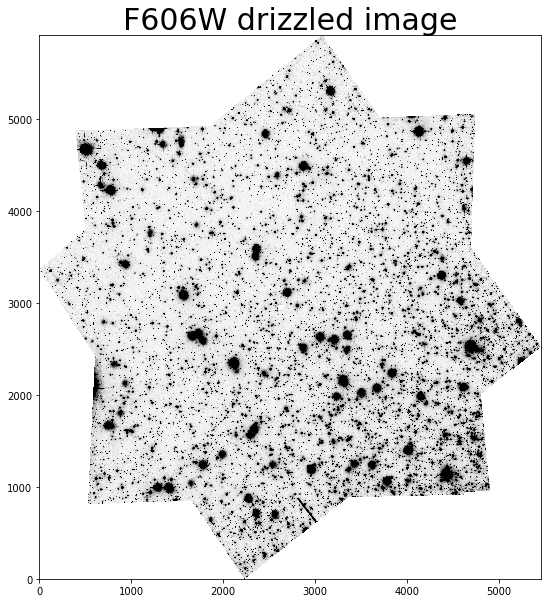

```python
plt.figure(figsize = (10, 10))
drc_dat = fits.open('f606w_combined_drc.fits')['SCI', 1].data #final drizzled image in SCI,1 extension
z1, z2 = zscale.get_limits(drc_dat)
plt.imshow(drc_dat, origin='lower', vmin=z1, vmax=z2, cmap='Greys')
plt.title('F606W drizzled image', fontsize=30)
```

### Inspect the final weight image

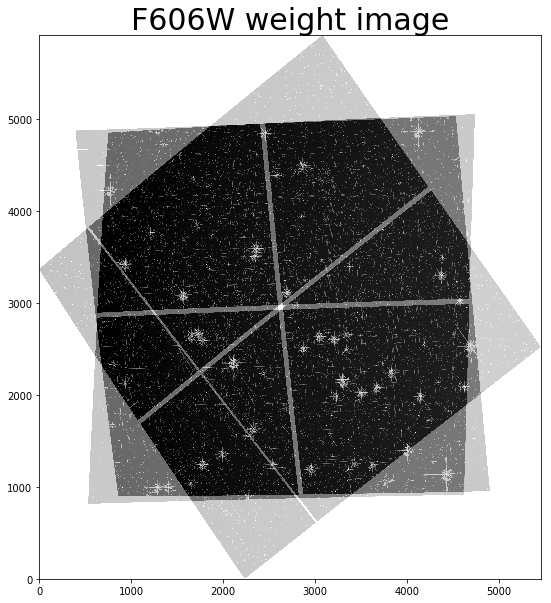

```python
plt.figure(figsize = (10, 10))
drc_dat = fits.open('f606w_combined_drc.fits')['WHT', 1].data #final drizzled image in WHT,1 extension
z1, z2 = zscale.get_limits(drc_dat)
plt.imshow(drc_dat, origin='lower', vmin=z1, vmax=z2, cmap='Greys')
plt.title('F606W weight image', fontsize=30)
```

## Discussion of AstroDrizzle

In this example, we imported and ran the `AstroDrizzle` task on our input images, which were previously aligned with `TweakReg`. By setting `configobj` to None, we ensured that `AstroDrizzle` was not picking up any existing configuration files and parameters were restored to default values. We then set a select few parameters to non-default values:

1. `output = 'f606w_combined'` : Output file name root (which will be appended with various suffixes). Defaults to input file name.
2. `driz_sep_bits = '64,16'` : Data quality flags in the `flt.fits` file, which were set during calibration, can be used as bit mask when drizzling. The user may specify which bit values should actually be considered "good" and included in image combination. In `astrodrizzle`, this parameter may be given as the sum of those DQ flags or as a comma-separated list, as shown in this example. In this example, 64 and 16 are set, so that both warm pixels and stable hot pixels, which are corrected by the dark, are treated as valid input pixels.
3. `driz_cr_corr = True` : When set to True, the task will create both a cosmic ray mask image (suffix `crmask.fits`) and a clean version of the original input images (suffix `crclean.fits`), where flagged pixels are replaced by pixels from the blotted median. It is strongly recommended that the quality of the cosmic ray masks be verified by blinking the original `flt.fits` input image with both the cosmic ray-cleaned image (`crclean.fits`) and the cosmic-ray mask (`crmask.fits`).
4. `final_bits = '64,16'` : Similar to `driz_sep_bits`, but for the last step when all the input images are combined.
5. `clean = False` : intermediate output files (e.g masks) will be kept. If True, only main outputs will be kept. Also see `in_memory` to control this behavior.
6. `configobj = None` : ignore any TEAL inputs / config files and refresh all parameters to default values.

`AstroDrizzle` has a large number of parameters, which are [described here](https://drizzlepac.readthedocs.io/en/deployment/astrodrizzle.html). Running `AstroDrizzle` using default parameter values is not recommended, as these defaults may not provide optimal science products. Users should also inspect the quality of the sky subtraction and cosmic ray rejection. For dithered data, users may experiment with the output `final_scale` and `final_pixfrac` parameters in the `final_drizzle` step. For more details, see the notebook in this repository to 'Optimize Image Sampling'.

# About this Notebook

```
Author: C. Shanahan, STScI WFC3 Team
Updated: December 17, 2018
```